# **Malaria Detection**

##### Project Developed within MIT

## **Problem Definition**

##### **The Context:**

- Malaria is a life-threatening disease caused by Plasmodium parasites and early detection is crucial for effective treatment.
- Accurate and timely diagnosis can significantly reduce mortality rates especially in regions with limited medical resources.

##### **The Problem Formulation:**

- The task is to use data science particularly Deep learning and image processing techniques to classify blood cells as either parasitized or uninfected.
- The goal is to build a model that maximizes accuracy and minimizes false diagnoses with low computation cost.

##### **The Objectives:**

- The primary aim is to develop an accurate and efficient model that can automatically detect malaria-infected cells from microscopic images.
- This model should assist healthcare professionals in countries with limited resources in diagnosing malaria quickly and accurately.

##### **The Key Questions:**

- How accurately can the model distinguish between parasitized and uninfected cells?
- What is the optimal architecture and preprocessing techniques needed to achieve high accuracy?
- How does data augmentation and model complexity affect performance on this specific dataset?

## **Data Description**

There are a total of 24,958 train and 2,600 test images (colored) that we have taken from microscopic images. These images are of the following categories:

**Parasitized:** The parasitized cells contain the Plasmodium parasite which causes malaria  
**Uninfected:** The uninfected cells are free of the Plasmodium parasites

### **Mount the Drive**

```python
from google.colab import drive
drive.mount('/content/drive')
```

### **Loading libraries**

```python
import zipfile
import os
import numpy as np
import pandas as pd
from PIL import Image
from PIL import Image
import matplotlib.pyplot as plt
import seaborn as sns


# To ignore warnings
import warnings
warnings.filterwarnings('ignore')

# Remove the limit from the number of displayed columns and rows. It helps to see the entire dataframe while printing it
pd.set_option("display.max_columns", None)
pd.set_option("display.max_rows", 200)
```

## **Data Preparation**

### **Load the data**

```python
# Storing the path of the data file from Google Drive
path = '/content/drive/MyDrive/MIT/Projects/Capstone Project_Malaria Detection_Deep learning/Datasets/cell_images.zip'

# Extracting the files from the zip file
with zipfile.ZipFile(path, 'r') as zip_ref:
    zip_ref.extractall('/content/')
```

```python
# Defining the paths for train and test directories
train_directory_path = '/content/cell_images/train'
test_directory_path = '/content/cell_images/test'
```

### **Creating a function to Load and Label Images for a Binary Classification task**

```python
# Create a function to load images and their labels which could be used for train and test images and labels
def load_images_and_labels(directory, img_size=(64, 64)):
    images = []  # List to store the images
    labels = []  # List to store the labels

    for folder_name in ['/parasitized/', '/uninfected/']:  # Loop through both class directories
        images_path = os.listdir(directory + folder_name)  # List image files in parasitized or uninfected

        for image_name in images_path: # Loop through each image file

        #We will use the try block  to handle potential errors that might occur while processing each image file
            try:
                #  open the image file with PIL library that is used to open an image file.
                image = Image.open(directory + folder_name + image_name)

                # Resize the image to the specified size
                image = image.resize(img_size)

                # Convert the image to a numpy array and append to the images list
                images.append(np.array(image))

                if folder_name == '/parasitized/':
                    labels.append(1)  # If the image is from the parasitized folder append label 1
                else:
                    labels.append(0) # If the image is from the uninfected folder append label 0

            except Exception as e:
                print(f'Error processing {image_name}: {e}')  # Catch any exceptions that occur during image processing Print the error message
                pass  # Skip to the next image

    return np.array(images), np.array(labels)  # Return the images and labels as numpy arrays
```

- The extracted folder has different folders for train and test data will contain the different sizes of images for parasitized and uninfected cells within the respective folder name.
- The size of all images must be the same and should be converted to 4D arrays so that they can be used as an input for the convolutional neural network. - Also it is important to create the labels for both types of images to be able to train and test the model.

Let's do the same for the training data first and then we will use the same code for the test data as well.

```python
# Loading train and test images and labels using the function
train_images, train_labels = load_images_and_labels(train_directory_path)
test_images, test_labels = load_images_and_labels(test_directory_path)
```

### **Check the shape of train and Test images**

```python
# Print the shape of the datasets to verify
print('Train images shape:', train_images.shape)
print('Test images shape:', test_images.shape)
```

```
Train images shape: (24958, 64, 64, 3)
Test images shape: (2600, 64, 64, 3)
```

### **Check the shape of Train and Test labels**

```python
print("Train labels shape:", train_labels.shape)  # Print the shape of the training labels array
print("Test labels shape:", test_labels.shape)  # Print the shape of the testing labels array
```

```
Train labels shape: (24958,)
Test labels shape: (2600,)
```

#### **Observations:**

- The uniform image size of 64 x 64 pixels and 3 indicating the RGB of the given dataset shows that preprocessing steps have been taken to standardize the images which is important for ensuring a smooth and efficient model performance.
- The training labels array has 24.958 samples and the test labels array has 2.600 samples, both labeled as either parasitized (1) or uninfected (0) in a binary structure.

### **Check the minimum and maximum range of pixel values for train and test images.**

```python
# Check the minimum and maximum range of pixel values for train and test images
print("Train images pixel range:", np.min(train_images), "to", np.max(train_images))
print("Test images pixel range:", np.min(test_images), "to", np.max(test_images))
```

```
Train images pixel range: 0 to 255
Test images pixel range: 0 to 255
```

#### **Observations:**

Train Images Pixel Range: The pixel values for the train images range from 0 to 255 which is normal for RGB images where each pixel's intensity ranges from 0 (black) to 255 (white). Test Images Pixel Range: The pixel values for the test images also range from 0 to 255 as per the train images.

### **Count the number of values in Uninfected and Parasitized cells.**

```python
# Calculate the number of parasitized and uninfected images in train and test datasets
train_parasitized_count = np.sum(train_labels == 1)
train_uninfected_count = np.sum(train_labels == 0)
test_parasitized_count = np.sum(test_labels == 1)
test_uninfected_count = np.sum(test_labels == 0)

# Print the counts
print("Number of parasitized images in train dataset:", train_parasitized_count)
print("Number of uninfected images in train dataset:", train_uninfected_count)
print("Number of parasitized images in test dataset:", test_parasitized_count)
print("Number of uninfected images in test dataset:", test_uninfected_count)
```

```
Number of parasitized images in train dataset: 12582
Number of uninfected images in train dataset: 12376
Number of parasitized images in test dataset: 1300
Number of uninfected images in test dataset: 1300
```

### **Normalize the images**

```python
train_images= (train_images/255).astype('float32')
test_images= (test_images/255).astype('float32')
```

#### **Observations and Insights:**

Normalizing the images helps improving the model performance and contribute to the robustness of the model's training and evaluation process.

## **Data Exploration**

### **Use a Pie Chart plot to check if the datas are balanced**

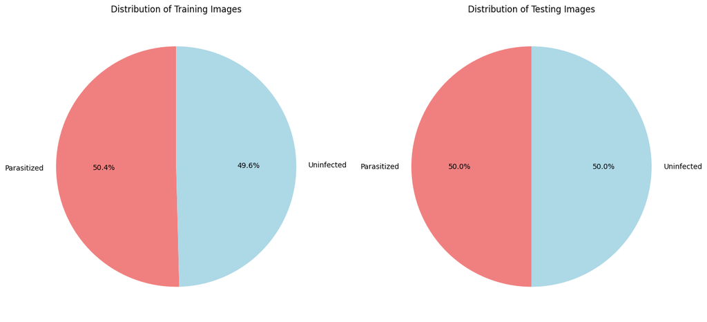

```python
# Data used for pie chart
train_counts = [train_parasitized_count, train_uninfected_count]
test_counts = [test_parasitized_count, test_uninfected_count]
labels = ['Parasitized', 'Uninfected']

# Ploting the pie chart for train and test Images
plt.figure(figsize=(14, 7))

plt.subplot(1, 2, 1)
plt.pie(train_counts, labels=labels, autopct='%1.1f%%', startangle=90, colors=['lightcoral', 'lightblue'])
plt.title('Distribution of Training Images')

plt.subplot(1, 2, 2)
plt.pie(test_counts, labels=labels, autopct='%1.1f%%', startangle=90, colors=['lightcoral', 'lightblue'])
plt.title('Distribution of Testing Images')

plt.tight_layout()
plt.show()
```

#### **Observations and Insights:**

The number of parasitized and uninfected images in the train dataset is very balanced with a slight majority of parasitized images.

The test dataset is perfectly balanced with an equal number of parasitized and uninfected images. This balance is preventing the model from becoming biased toward one class during training also for the testing it ensures that it can be equally tested on both classes.

### **Let's visualize the images from the train data.**

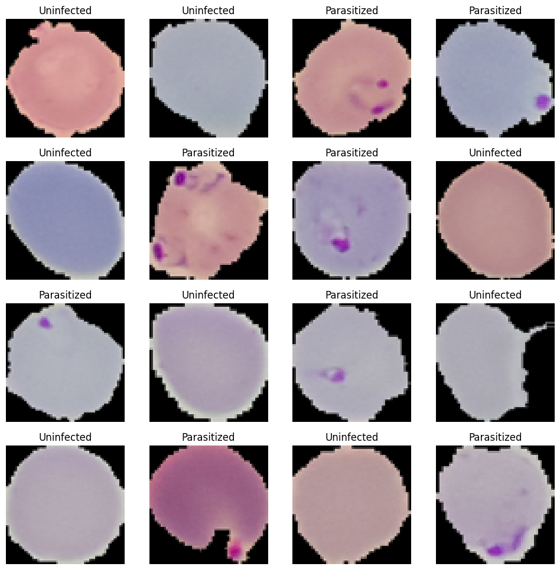

```python
#  Random seed for reproducibility
np.random.seed(42)

# Create a figure with a 4x4 grid of subplots
fig, axes = plt.subplots(4, 4, figsize=(12, 12))

# Flatten the axes array to avoid the use of nested loops
axes = axes.flatten()

# Go over again each subplot and display a random image
for ax in axes:
    # Randomly select an image index
    index = np.random.randint(0, train_images.shape[0])

    # Determine the title based on the label
    title = 'Parasitized' if train_labels[index] == 1 else 'Uninfected'

    # Display the image and set the title
    ax.imshow(train_images[index])
    ax.set_title(title)
    ax.axis('off')  # Turn off axis to avoid overlping

plt.show()
```

#### **Observations:**

The images are relatively clear and all are surounded with distinct boundaries between the cell and the background which will help the model to accurately differentiate shapes.

Also in general the color variation between parasitized and uninfected cells is noticeable with the parasitized cells having more color contrast and the uninfected cells to a more uniform color.

### **Visualize more images with subplot(6, 6) and figsize = (12, 12)**

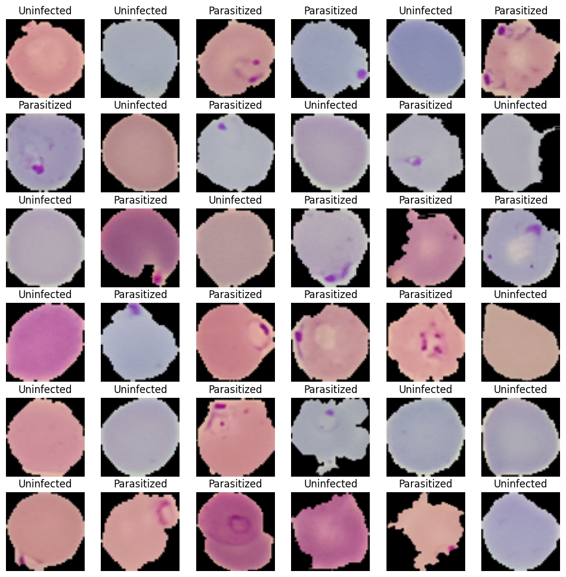

```python
#  Random seed for reproducibility
np.random.seed(42)

# Create a figure with a 4x4 grid of subplots
fig, axes = plt.subplots(6, 6, figsize=(12, 12))

# Flatten the axes array to avoid the use of nested loops
axes = axes.flatten()

# Go over again each subplot and display a random image
for ax in axes:
    # Randomly select an image index
    index = np.random.randint(0, train_images.shape[0])

    # Determine the title based on the label
    title = 'Parasitized' if train_labels[index] == 1 else 'Uninfected'

    # Display the image and set the title
    ax.imshow(train_images[index])
    ax.set_title(title)
    ax.axis('off')  # Turn off axis to avoid overlping

plt.show()
```

#### **Observations:**

Using larger subplot help us to confirm your previous observations. However we observe that some parasitized cells show minimal visible signs of infection making them difficult to distinguish from uninfected cells. This could require the model to be highly sensitive to subtle differences in the images.

### **Plotting the mean images for parasitized and uninfected**

```python
# Function to find the mean
def find_mean_img(full_mat, title):
    # Calculate the average
    mean_img = np.mean(full_mat, axis = 0)

    # Reshape it back to a matrix
    plt.imshow(mean_img)

    plt.title(f'Average {title}')
    plt.axis('off')
    plt.show()

    return mean_img
```

```python
parasitized_data = []  # Create a list to store the parasitized data
uninfected_data = []   # Create a list to store the uninfected data

for img, label in zip(train_images, train_labels):
    if label == 1:
        parasitized_data.append(img)
    elif label == 0:
        uninfected_data.append(img)
```

**Mean image for parasitized**

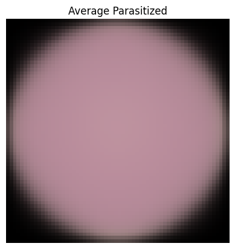

```python
parasitized_mean = find_mean_img(np.array(parasitized_data), 'Parasitized')
```

**Mean image for uninfected**

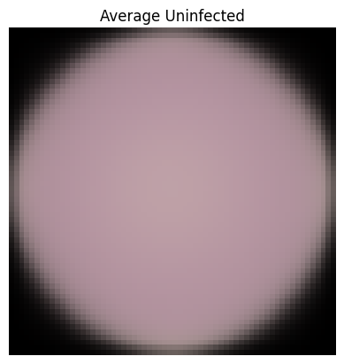

```python
uninfected_mean = find_mean_img(np.array(uninfected_data), 'Uninfected')
```

#### **Observations:**

The mean images for both parasitized and uninfected cells look quite similar in overall structure. The mean image for parasitized cells appears to have a slightly more pronounced coloration compared to the uninfected cells particularly in the central region. Since the differences between parasitized and uninfected cells are subtle, the model will need to be sensitive to small changes in pixel values.

## **Further Images manipulations by Converting RGB to HSV of Images using OpenCV**

### **Converting the train data**

[output not shown]

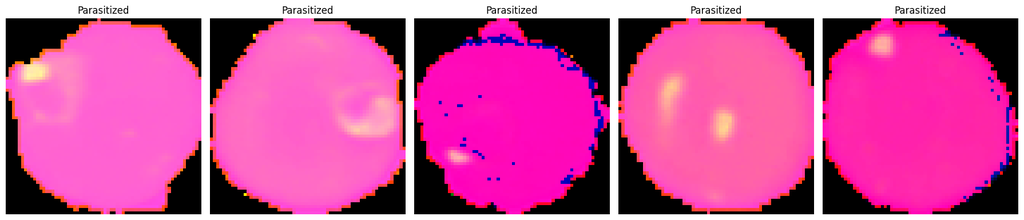

```python
import cv2


# Convert the first 100 train images from RGB to HSV and store them in gfx
gfx = []  # To hold the HSV image array

for i in np.arange(0, 100, 1):
    a = cv2.cvtColor(train_images[i], cv2.COLOR_BGR2HSV)  # Correct conversion for RGB to HSV
    gfx.append(a)

gfx = np.array(gfx)

# Randomly select 5 images for visualization
viewimage = np.random.randint(1, 100, 5)

# Create a figure to display the images
fig, ax = plt.subplots(1, 5, figsize=(18, 18))

# Loop through the selected images and display them
for t, i in zip(range(5), viewimage):
    Title = 'Parasitized' if train_labels[i] == 1 else 'Uninfected'
    ax[t].set_title(Title)
    ax[t].imshow(gfx[i])
    ax[t].set_axis_off()

fig.tight_layout()
plt.show()
```

### **Converting the test data**

[output not shown]

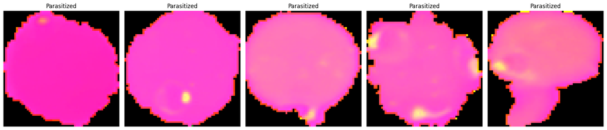

```python
# Similarly, visualize images in the test dataset
gfx_test = []  # To hold the HSV image array for test images

for i in np.arange(0, 100, 1):
    a = cv2.cvtColor(test_images[i], cv2.COLOR_BGR2HSV)  # Correct conversion for RGB to HSV
    gfx_test.append(a)

gfx_test = np.array(gfx_test)

# Randomly select 5 test images for visualization
viewimage_test = np.random.randint(1, 100, 5)

# Create a figure to display the test images
fig, ax = plt.subplots(1, 5, figsize=(18, 18))

# Loop through the selected test images and display them
for t, i in zip(range(5), viewimage_test):
    Title = 'Parasitized' if test_labels[i] == 1 else 'Uninfected'
    ax[t].set_title(Title)
    ax[t].imshow(gfx_test[i])
    ax[t].set_axis_off()

fig.tight_layout()
plt.show()
```

#### **Observations and insights:**

The more pronounced contrast and color differentiation in the HSV images could provide a significant advantage in training a model to accurately classify parasitized and uninfected cells.

How ever while the HSV color can enhance certain features the model must be capable of interpreting it. Meaning that the model's architecture may need considerable adjustments to be able to utilize the benefits of HSV representation.

## **Further Images manipulations by using Gaussian Blurring**

### **Gaussian Blurring on train data**

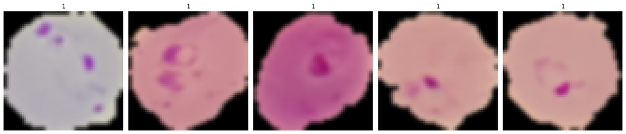

```python
gbx = []  # To hold the blurred images

for i in np.arange(0, 100, 1):

  b = cv2.GaussianBlur(train_images[i], (5, 5), 0)

  gbx.append(b)

gbx = np.array(gbx)

viewimage = np.random.randint(1, 100, 5)

fig, ax = plt.subplots(1, 5, figsize = (18, 18))

for t, i in zip(range(5), viewimage):

  Title = train_labels[i]

  ax[t].set_title(Title)


  ax[t].imshow(gbx[i])

  ax[t].set_axis_off()

  fig.tight_layout()
```

### **Gaussian Blurring on test data**

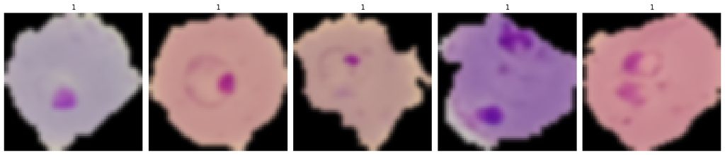

```python
gbx_test= []  # To hold the blurred images

for i in np.arange(0, 100, 1):

  b = cv2.GaussianBlur(test_images[i], (5, 5), 0)

  gbx_test.append(b)

gbx_test = np.array(gbx)

viewimage_test = np.random.randint(1, 100, 5)

fig, ax = plt.subplots(1, 5, figsize = (18, 18))

for t, i in zip(range(5), viewimage_test):

  Title = test_labels[i]

  ax[t].set_title(Title)


  ax[t].imshow(gbx_test[i])

  ax[t].set_axis_off()

  fig.tight_layout()
```

#### **Observations and Insights:**

The images show a smoothing bluring effect softens the edges and reduces the sharpness of the image making the features appearing more diffused.

- **Would blurring help us for this problem statement in any way?**
- Gaussian Blurring can reduce noise and simplify images but it can also hide important details needed for accurate classification. The balance between noise reduction and feature preservation is important especially for tasks like identifying parasitized cells.
- **What else can we try?**
- We could try "Color Jittering" with Advanced Image Augmentation introducing changes in(HSV).

# **Model Building**

### **Importing the required libraries for building and training our CNN Models**

```python
from sklearn.model_selection import train_test_split
#For scaling features which preparing the steps to normalize the data
from sklearn.preprocessing import MinMaxScaler

# For building training and evaluating neural networks.
import tensorflow as tf

# The Sequential class in tensorflow.keras provides an easy way to build neural network models by stacking layers sequentially.
from tensorflow.keras.models import Sequential

# Importing all the different layers and optimizers
from tensorflow.keras.layers import Dense, Dropout, Flatten, Conv2D, MaxPooling2D, BatchNormalization, Activation, LeakyReLU
from tensorflow.keras.optimizers import Adam,SGD

# To convert integers into one-hot encoded vectors
from tensorflow.keras.utils import to_categorical

# Classification tasks with one-hot encoded targets measuring true vs. predicted probabilities
from tensorflow.keras.losses import categorical_crossentropy

# For randomly rearrange the elements of a list in place.
from random import shuffle

# EarlyStopping prevents overfitting by halting training when no improvement is seen.
# ModelCheckpoint saves the best model during training. shuffle randomizes the order of
from tensorflow.keras.callbacks import EarlyStopping, ModelCheckpoint

# provides various functions to generate random numbers
import random

# For randomly rearrange the elements of a list in place.
from random import shuffle
```

### **One Hot Encoding the Train and Test labels**

```python
# Visulaize the first 5 entries before applying one hot encoding
print("Five first entries before applying one hot encoding to the train labels:\n", train_labels[:5])
print("Five first entries before applying one hot encoding to the test labels:\n", test_labels[:5])
```

```
Five first entries before applying one hot encoding to the train labels:
 [1 1 1 1 1]
Five first entries before applying one hot encoding to the test labels:
 [1 1 1 1 1]
```

```python
# Apply one-hot encoding to the labels
train_labels = to_categorical(train_labels, num_classes=2)
test_labels = to_categorical(test_labels, num_classes=2)
```

```python
# Print the shapes to verify
print("Train labels one-hot shape:", train_labels.shape)
print("Test labels one-hot shape:", test_labels.shape)

# Visulaize the first 5 entries after applying one hot encoding
print("Five first entries after applying one hot encoding to the train labels:\n", train_labels[:5])
print("Five first entries after applying one hot encoding to the test labels:\n", test_labels[:5])
```

```
Train labels one-hot shape: (24958, 2)
Test labels one-hot shape: (2600, 2)
Five first entries after applying one hot encoding to the train labels:
 [[0. 1.]
 [0. 1.]
 [0. 1.]
 [0. 1.]
 [0. 1.]]
Five first entries after applying one hot encoding to the test labels:
 [[0. 1.]
 [0. 1.]
 [0. 1.]
 [0. 1.]
 [0. 1.]]
```

#### **Observations and insights:**

- The one-hot encoding process has converted each label into a binary vector of length 2 where each vector element corresponds to one of the two classes "parasitized" or "uninfected".
- After one-hot encoding, the labels for parasitized cells are represented by [0. 1.] and for uninfected cells, they would be represented by [1. 0.]. This transformation allows for better representation and interpretation of the classification problem.

## Building **"Base-Model"**

**Note:** This Base-Model has been fully built and evaluated with all outputs shown to optimise and give an idea about the process of the creation and evaluation of the performance of a CNN architecture. A similar process can be followed in iterating to build better-performing CNN architectures.

```python
# Clearing back end
from tensorflow.keras import backend
backend.clear_session()
```

```python
# Fixing the seed at 42 for random number generators
import random
np.random.seed(42)
random.seed(42)
tf.random.set_seed(42)
```

```python
def Base_Model():
    model = Sequential()

    # First Convolutional layer with kernel size of 2x2
    model.add(Conv2D(32, (2, 2), padding='same', activation='relu', input_shape=(64, 64, 3)))
    model.add(MaxPooling2D(pool_size=(2, 2)))
    model.add(Dropout(0.2))

    # Second Convolutional layer with kernel size of 2x2
    model.add(Conv2D(32, (2, 2), padding='same', activation='relu'))
    model.add(MaxPooling2D(pool_size=(2, 2)))
    model.add(Dropout(0.2))

    # Third Convolutional layer with  kernel size of 2x2 and
    model.add(Conv2D(32, (2, 2), padding='same', activation='relu'))
    model.add(MaxPooling2D(pool_size=(2, 2)))
    model.add(Dropout(0.2))


    model.add(Flatten())

    # Dense layer
    model.add(Dense(512, activation='relu'))
    model.add(Dropout(0.4))

    # Output layer
    model.add(Dense(2, activation='softmax'))  # 2 represents output layer neurons


    # Compile the model
    model.compile(loss='binary_crossentropy', optimizer='adam', metrics=['accuracy'])

    return model
```

```python
# create Base Model using the function and print its summary
Base_Model = Base_Model()
Base_Model.summary()
```

```
Model: "sequential"
```

```
┏━━━━━━━━━━━━━━━━━━━━━━━━━━━━━━━━━━━━━━┳━━━━━━━━━━━━━━━━━━━━━━━━━━━━━┳━━━━━━━━━━━━━━━━━┓
┃ Layer (type)                         ┃ Output Shape                ┃         Param # ┃
┡━━━━━━━━━━━━━━━━━━━━━━━━━━━━━━━━━━━━━━╇━━━━━━━━━━━━━━━━━━━━━━━━━━━━━╇━━━━━━━━━━━━━━━━━┩
│ conv2d (Conv2D)                      │ (None, 64, 64, 32)          │             416 │
├──────────────────────────────────────┼─────────────────────────────┼─────────────────┤
│ max_pooling2d (MaxPooling2D)         │ (None, 32, 32, 32)          │               0 │
├──────────────────────────────────────┼─────────────────────────────┼─────────────────┤
│ dropout (Dropout)                    │ (None, 32, 32, 32)          │               0 │
├──────────────────────────────────────┼─────────────────────────────┼─────────────────┤
│ conv2d_1 (Conv2D)                    │ (None, 32, 32, 32)          │           4,128 │
├──────────────────────────────────────┼─────────────────────────────┼─────────────────┤
│ max_pooling2d_1 (MaxPooling2D)       │ (None, 16, 16, 32)          │               0 │
├──────────────────────────────────────┼─────────────────────────────┼─────────────────┤
│ dropout_1 (Dropout)                  │ (None, 16, 16, 32)          │               0 │
├──────────────────────────────────────┼─────────────────────────────┼─────────────────┤
│ conv2d_2 (Conv2D)                    │ (None, 16, 16, 32)          │           4,128 │
├──────────────────────────────────────┼─────────────────────────────┼─────────────────┤
│ max_pooling2d_2 (MaxPooling2D)       │ (None, 8, 8, 32)            │               0 │
├──────────────────────────────────────┼─────────────────────────────┼─────────────────┤
│ dropout_2 (Dropout)                  │ (None, 8, 8, 32)            │               0 │
├──────────────────────────────────────┼─────────────────────────────┼─────────────────┤
│ flatten (Flatten)                    │ (None, 2048)                │               0 │
├──────────────────────────────────────┼─────────────────────────────┼─────────────────┤
│ dense (Dense)                        │ (None, 512)                 │       1,049,088 │
├──────────────────────────────────────┼─────────────────────────────┼─────────────────┤
│ dropout_3 (Dropout)                  │ (None, 512)                 │               0 │
├──────────────────────────────────────┼─────────────────────────────┼─────────────────┤
│ dense_1 (Dense)                      │ (None, 2)                   │           1,026 │
└──────────────────────────────────────┴─────────────────────────────┴─────────────────┘
```

```
 Total params: 1,058,786 (4.04 MB)
```

```
 Trainable params: 1,058,786 (4.04 MB)
```

```
 Non-trainable params: 0 (0.00 B)
```

#### **Using Callbacks**

```python
callbacks = [EarlyStopping(monitor = 'val_loss', patience = 2),
             ModelCheckpoint('/content/drive/MyDrive/MIT/Projects/Capstone Project_Malaria Detection_Deep learning/Notebooks/call backs/Base_Model.keras', monitor = 'val_loss', save_best_only = True)]
```

#### **Fit and train the model**

```python
# Fit the model with min batch size as 32 can tune batch size to some factor of 2^power ]
Base_Model_history = Base_Model.fit(train_images, train_labels, batch_size = 32, callbacks = callbacks, validation_split = 0.2, epochs = 20, verbose = 1)
```

```
624/624 ━━━━━━━━━━━━━━━━━━━━ 113s 178ms/step - accuracy: 0.7206 - loss: 0.5372 - val_accuracy: 0.9555 - val_loss: 0.1136
624/624 ━━━━━━━━━━━━━━━━━━━━ 141s 176ms/step - accuracy: 0.9505 - loss: 0.1352 - val_accuracy: 0.9690 - val_loss: 0.1100
624/624 ━━━━━━━━━━━━━━━━━━━━ 127s 151ms/step - accuracy: 0.9619 - loss: 0.1126 - val_accuracy: 0.9810 - val_loss: 0.1235
624/624 ━━━━━━━━━━━━━━━━━━━━ 141s 150ms/step - accuracy: 0.9714 - loss: 0.0924 - val_accuracy: 0.9938 - val_loss: 0.0538
624/624 ━━━━━━━━━━━━━━━━━━━━ 146s 157ms/step - accuracy: 0.9749 - loss: 0.0734 - val_accuracy: 0.9878 - val_loss: 0.0626
624/624 ━━━━━━━━━━━━━━━━━━━━ 149s 169ms/step - accuracy: 0.9760 - loss: 0.0688 - val_accuracy: 0.9846 - val_loss: 0.0690
```

#### **Evaluating "Base-Model" on test data**

```python
# Evaluate the model
loss, accuracy = Base_Model.evaluate(test_images, test_labels, verbose=1)

# Print the loss and accuracy
print('Test Loss:', loss)
print('Test Accuracy:', accuracy)
```

```
82/82 ━━━━━━━━━━━━━━━━━━━━ 3s 32ms/step - accuracy: 0.9812 - loss: 0.0660
Test Loss: 0.06836951524019241
Test Accuracy: 0.9830769300460815
```

#### **Plotting the train and validation curves**

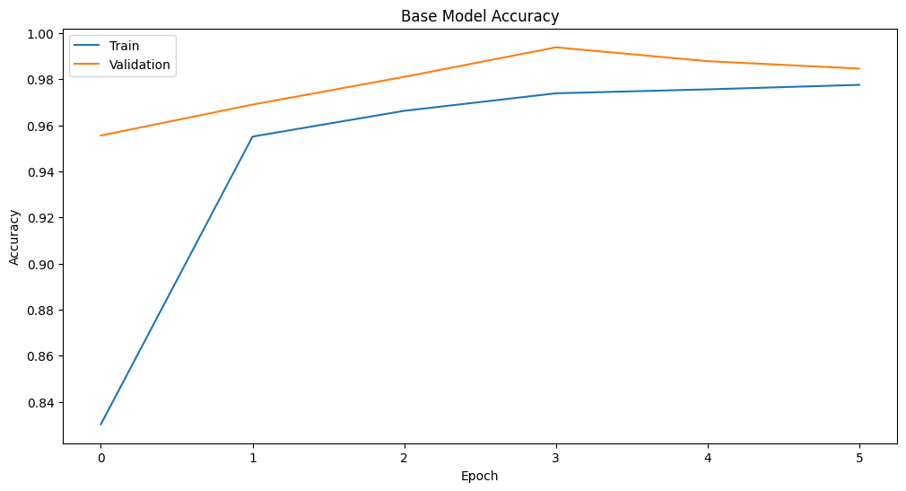

```python
# Plot training & validation accuracy values
plt.figure(figsize=(12, 6))

plt.plot(Base_Model_history.history['accuracy'], label='Train Accuracy')
plt.plot(Base_Model_history.history['val_accuracy'], label='Validation Accuracy')
plt.title('Base Model Accuracy')
plt.xlabel('Epoch')
plt.ylabel('Accuracy')
plt.legend(['Train', 'Validation'], loc='upper left')

plt.show()
```

#### **Plotting the confusion matrix**

```
              precision    recall  f1-score   support

           0       0.98      0.99      0.98      1300
           1       0.99      0.98      0.98      1300

    accuracy                           0.98      2600
   macro avg       0.98      0.98      0.98      2600
weighted avg       0.98      0.98      0.98      2600
```

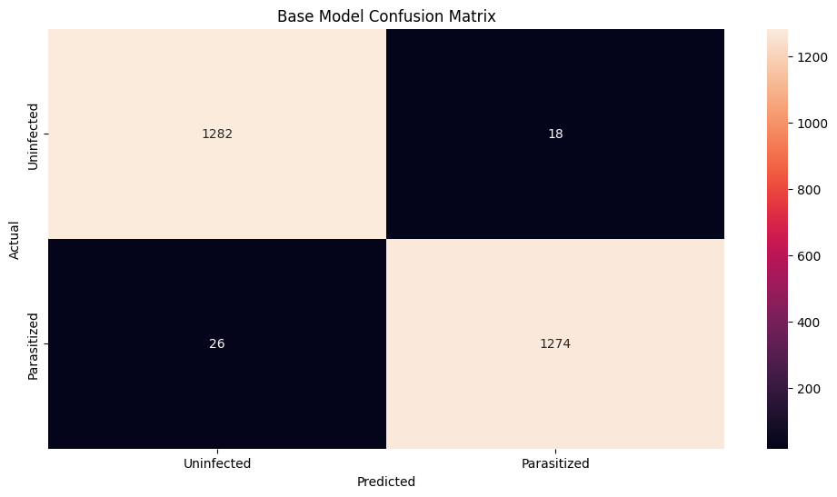

```python
# Make predictions on the test set using Base model
Base_Model_pred = Base_Model.predict(test_images)

# Convert the predicted probabilities to class labels
Base_Model_pred = np.argmax(Base_Model_pred, axis= 1)

# Convert one-hot encoded vectors to single labels for true test labels
True_class_labels = np.argmax(test_labels, axis= 1)

# Importing required functions
from sklearn.metrics import classification_report
from sklearn.metrics import confusion_matrix

# Printing the classification report
print(classification_report(True_class_labels, Base_Model_pred ))

# Create the confusion matrix
confusion_matrix = tf.math.confusion_matrix(True_class_labels, Base_Model_pred)

# Ploting the heatmap using confusion matrix
plt.figure(figsize = (12, 6))
sns.heatmap(confusion_matrix, annot = True,  fmt = '.0f', xticklabels = ['Uninfected', 'Parasitized'], yticklabels = ['Uninfected', 'Parasitized'])
plt.title('Base Model Confusion Matrix')
plt.xlabel('Predicted')
plt.ylabel('Actual')

plt.show()
```

#### **Observations:**

**"Base-Model"** uses smaller 2x2 kernels and a simpler architecture with fewer filters leading to a model with a moderate number of parameters.

## Building **"Model-1"**

- Trying to improve the performance of the base model by adding new layers and activation functions.
- Model-1 is using BatchNormalization and LeakyReLU as the activation function, with additional layers and dropout added after the flatten layer.

```python
# Clearing back end
from tensorflow.keras import backend
backend.clear_session()

# Fixing the seed at 42 for random number generators
import random
np.random.seed(42)
random.seed(42)
tf.random.set_seed(42)
```

```python
def Model_1():
    model = Sequential()

    # First Convolutional layer
    model.add(Conv2D(32, (3, 3), padding='same',input_shape=(64, 64, 3)))
    model.add(LeakyReLU(alpha=0.1))
    model.add(BatchNormalization())
    model.add(MaxPooling2D(pool_size=(2, 2)))

    # First Convolutional layer
    model.add(Conv2D(32, (3, 3), padding='same'))
    model.add(LeakyReLU(alpha=0.1))
    model.add(BatchNormalization())
    model.add(MaxPooling2D(pool_size=(2, 2)))


    # Second Convolutional layer
    model.add(Conv2D(64, (3, 3), padding='same'))
    model.add(LeakyReLU(alpha=0.1))
    model.add(BatchNormalization())
    model.add(MaxPooling2D(pool_size=(2, 2)))

    # Second Convolutional layer
    model.add(Conv2D(64, (3, 3), padding='same'))
    model.add(LeakyReLU(alpha=0.1))
    model.add(BatchNormalization())
    model.add(MaxPooling2D(pool_size=(2, 2)))


    # Third Convolutional layer
    model.add(Conv2D(128, (3, 3), padding='same'))
    model.add(LeakyReLU(alpha=0.1))
    model.add(BatchNormalization())
    model.add(MaxPooling2D(pool_size=(2, 2)))

    # Third Convolutional layer
    model.add(Conv2D(128, (3, 3), padding='same'))
    model.add(LeakyReLU(alpha=0.1))
    model.add(BatchNormalization())
    model.add(MaxPooling2D(pool_size=(2, 2)))

    # Flatten the output
    model.add(Flatten())

    # Dense layer with ReLU activation
    model.add(Dense(1024, activation='relu'))
    model.add(Dropout(0.3))

    # Dense layer with ReLU activation
    model.add(Dense(512, activation='relu'))

    # Final output layer
    model.add(Dense(2, activation='softmax'))


    # Compile the model
    model.compile(loss='binary_crossentropy',optimizer=Adam(learning_rate=0.001), metrics=['accuracy'])

    return model
```

```python
# create Model 1 using the function and print its summary
Model_1 = Model_1()
Model_1.summary()
```

```
Model: "sequential"
```

```
┏━━━━━━━━━━━━━━━━━━━━━━━━━━━━━━━━━━━━━━┳━━━━━━━━━━━━━━━━━━━━━━━━━━━━━┳━━━━━━━━━━━━━━━━━┓
┃ Layer (type)                         ┃ Output Shape                ┃         Param # ┃
┡━━━━━━━━━━━━━━━━━━━━━━━━━━━━━━━━━━━━━━╇━━━━━━━━━━━━━━━━━━━━━━━━━━━━━╇━━━━━━━━━━━━━━━━━┩
│ conv2d (Conv2D)                      │ (None, 64, 64, 32)          │             896 │
├──────────────────────────────────────┼─────────────────────────────┼─────────────────┤
│ leaky_re_lu (LeakyReLU)              │ (None, 64, 64, 32)          │               0 │
├──────────────────────────────────────┼─────────────────────────────┼─────────────────┤
│ batch_normalization                  │ (None, 64, 64, 32)          │             128 │
│ (BatchNormalization)                 │                             │                 │
├──────────────────────────────────────┼─────────────────────────────┼─────────────────┤
│ max_pooling2d (MaxPooling2D)         │ (None, 32, 32, 32)          │               0 │
├──────────────────────────────────────┼─────────────────────────────┼─────────────────┤
│ conv2d_1 (Conv2D)                    │ (None, 32, 32, 32)          │           9,248 │
├──────────────────────────────────────┼─────────────────────────────┼─────────────────┤
│ leaky_re_lu_1 (LeakyReLU)            │ (None, 32, 32, 32)          │               0 │
├──────────────────────────────────────┼─────────────────────────────┼─────────────────┤
│ batch_normalization_1                │ (None, 32, 32, 32)          │             128 │
│ (BatchNormalization)                 │                             │                 │
├──────────────────────────────────────┼─────────────────────────────┼─────────────────┤
│ max_pooling2d_1 (MaxPooling2D)       │ (None, 16, 16, 32)          │               0 │
├──────────────────────────────────────┼─────────────────────────────┼─────────────────┤
│ conv2d_2 (Conv2D)                    │ (None, 16, 16, 64)          │          18,496 │
├──────────────────────────────────────┼─────────────────────────────┼─────────────────┤
│ leaky_re_lu_2 (LeakyReLU)            │ (None, 16, 16, 64)          │               0 │
├──────────────────────────────────────┼─────────────────────────────┼─────────────────┤
│ batch_normalization_2                │ (None, 16, 16, 64)          │             256 │
│ (BatchNormalization)                 │                             │                 │
├──────────────────────────────────────┼─────────────────────────────┼─────────────────┤
│ max_pooling2d_2 (MaxPooling2D)       │ (None, 8, 8, 64)            │               0 │
├──────────────────────────────────────┼─────────────────────────────┼─────────────────┤
│ conv2d_3 (Conv2D)                    │ (None, 8, 8, 64)            │          36,928 │
├──────────────────────────────────────┼─────────────────────────────┼─────────────────┤
│ leaky_re_lu_3 (LeakyReLU)            │ (None, 8, 8, 64)            │               0 │
├──────────────────────────────────────┼─────────────────────────────┼─────────────────┤
│ batch_normalization_3                │ (None, 8, 8, 64)            │             256 │
│ (BatchNormalization)                 │                             │                 │
├──────────────────────────────────────┼─────────────────────────────┼─────────────────┤
│ max_pooling2d_3 (MaxPooling2D)       │ (None, 4, 4, 64)            │               0 │
├──────────────────────────────────────┼─────────────────────────────┼─────────────────┤
│ conv2d_4 (Conv2D)                    │ (None, 4, 4, 128)           │          73,856 │
```

[output cut: 12 more lines]

```
│ batch_normalization_5                │ (None, 2, 2, 128)           │             512 │
│ (BatchNormalization)                 │                             │                 │
├──────────────────────────────────────┼─────────────────────────────┼─────────────────┤
│ max_pooling2d_5 (MaxPooling2D)       │ (None, 1, 1, 128)           │               0 │
├──────────────────────────────────────┼─────────────────────────────┼─────────────────┤
│ flatten (Flatten)                    │ (None, 128)                 │               0 │
├──────────────────────────────────────┼─────────────────────────────┼─────────────────┤
│ dense (Dense)                        │ (None, 1024)                │         132,096 │
├──────────────────────────────────────┼─────────────────────────────┼─────────────────┤
│ dropout (Dropout)                    │ (None, 1024)                │               0 │
├──────────────────────────────────────┼─────────────────────────────┼─────────────────┤
│ dense_1 (Dense)                      │ (None, 512)                 │         524,800 │
├──────────────────────────────────────┼─────────────────────────────┼─────────────────┤
│ dense_2 (Dense)                      │ (None, 2)                   │           1,026 │
└──────────────────────────────────────┴─────────────────────────────┴─────────────────┘
```

```
 Total params: 946,722 (3.61 MB)
```

```
 Trainable params: 945,826 (3.61 MB)
```

```
 Non-trainable params: 896 (3.50 KB)
```

#### **Using Callbacks**

```python
callbacks = [EarlyStopping(monitor = 'val_loss', patience = 3),
             ModelCheckpoint('/content/drive/MyDrive/MIT/Projects/Capstone Project_Malaria Detection_Deep learning/Notebooks/call backs/Model_01.keras', monitor = 'val_loss', save_best_only = True)]
```

#### **Fit and Train the model**

```python
Model_1_history = Model_1.fit(train_images, train_labels, batch_size = 32, callbacks = callbacks, validation_split = 0.2, epochs = 20, verbose = 1)
```

```
624/624 ━━━━━━━━━━━━━━━━━━━━ 206s 320ms/step - accuracy: 0.8953 - loss: 0.2472 - val_accuracy: 0.9858 - val_loss: 0.0412
624/624 ━━━━━━━━━━━━━━━━━━━━ 206s 326ms/step - accuracy: 0.9796 - loss: 0.0640 - val_accuracy: 0.9718 - val_loss: 0.0742
624/624 ━━━━━━━━━━━━━━━━━━━━ 253s 312ms/step - accuracy: 0.9799 - loss: 0.0588 - val_accuracy: 0.9786 - val_loss: 0.0494
624/624 ━━━━━━━━━━━━━━━━━━━━ 236s 378ms/step - accuracy: 0.9808 - loss: 0.0523 - val_accuracy: 0.9609 - val_loss: 0.0990
```

#### **Evaluating Model 1 on test data**

```python
# Evaluate the model
loss_model_1, accuracy_model_1 = Model_1.evaluate(test_images, test_labels, verbose=1)

# Print the loss and accuracy
print('Test Loss:', loss_model_1)
print('Test Accuracy:', accuracy_model_1)
```

```
82/82 ━━━━━━━━━━━━━━━━━━━━ 10s 120ms/step - accuracy: 0.9902 - loss: 0.0355
Test Loss: 0.06554263830184937
Test Accuracy: 0.9769230484962463
```

#### **Plotting the train and validation curves**

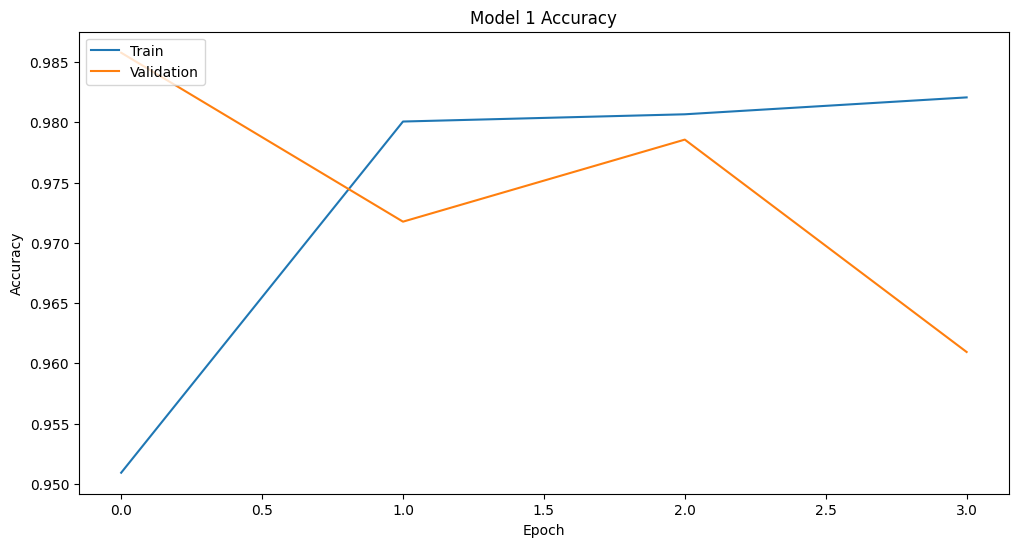

```python
# Plot training & validation accuracy values
plt.figure(figsize=(12, 6))

N = len(Model_1_history.history["accuracy"])

plt.plot(np.arange(0, N),Model_1_history.history['accuracy'], label='Train Accuracy')
plt.plot(np.arange(0, N),Model_1_history.history['val_accuracy'], label='Validation Accuracy')
plt.title('Model 1 Accuracy')
plt.xlabel('Epoch')
plt.ylabel('Accuracy')
plt.legend(['Train', 'Validation'], loc='upper left')

plt.show()
```

#### **Plotting the confusion matrix**

```
82/82 ━━━━━━━━━━━━━━━━━━━━ 10s 112ms/step
              precision    recall  f1-score   support

           0       0.99      0.96      0.98      1300
           1       0.96      0.99      0.98      1300

    accuracy                           0.98      2600
   macro avg       0.98      0.98      0.98      2600
weighted avg       0.98      0.98      0.98      2600
```

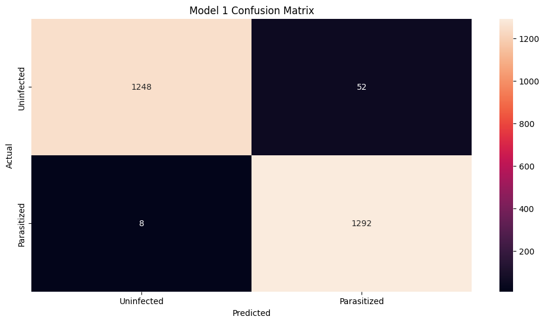

```python
# Make predictions on the test set using Model 1
Model_1_pred = Model_1.predict(test_images)

# Convert the predicted probabilities to class labels
Model_1_pred = np.argmax(Model_1_pred, axis= 1)

# Convert one-hot encoded vectors to single labels for true test labels
True_class_labels_model1 = np.argmax(test_labels, axis= 1)

# Importing required functions
from sklearn.metrics import classification_report
from sklearn.metrics import confusion_matrix

# Printing the classification report
print(classification_report(True_class_labels_model1, Model_1_pred  ))

# Create the confusion matrix
confusion_matrix = tf.math.confusion_matrix(True_class_labels_model1, Model_1_pred )

# Ploting the heatmap using confusion matrix
plt.figure(figsize = (12, 6))
sns.heatmap(confusion_matrix, annot = True,  fmt = '.0f', xticklabels = ['Uninfected', 'Parasitized'], yticklabels = ['Uninfected', 'Parasitized'])
plt.title('Model 1 Confusion Matrix')
plt.xlabel('Predicted')
plt.ylabel('Actual')

plt.show()
```

#### **Observations :**

Model 1 is more complex with more layers BatchNormalization & LeakyReLU activations and larger dense layers aiming for deeper learning despite fewer total parameters.

## Building **"Model-2"**

The model has a similar size to the Base Model however it uses larger kernel sizes of (3x3).

```python
# Clearing back end
from tensorflow.keras import backend
backend.clear_session()
```

```python
# Fixing the seed at 42 for random number generators
import random
np.random.seed(42)
random.seed(42)
tf.random.set_seed(42)
```

```python
def Model_2():
    model = Sequential()

    # First Convolutional layer with kernel size of 3x3
    model.add(Conv2D(32, (3, 3), padding='same', activation='relu', input_shape=(64, 64, 3)))

    model.add(MaxPooling2D(pool_size=(2, 2)))
    model.add(Dropout(0.2))

    # Second Convolutional layer with kernel size of 3x3
    model.add(Conv2D(32, (3, 3), padding='same', activation='relu'))

    model.add(MaxPooling2D(pool_size=(2, 2)))
    model.add(Dropout(0.2))

    # Third Convolutional layer with kernel size of 3x3
    model.add(Conv2D(32, (3, 3), padding='same', activation='relu'))

    model.add(MaxPooling2D(pool_size=(2, 2)))
    model.add(Dropout(0.2))

    # Flatten the output from the previous layer
    model.add(Flatten())

    # Dense layer with 512 nodes, BatchNormalization, and 'relu' activation
    model.add(Dense(512, activation='relu'))

    model.add(Dropout(0.4))

    # Final output layer with 2 nodes and 'softmax' activation
    model.add(Dense(2, activation='softmax'))  # 2 represents output layer neurons

    # Compile the model
    model.compile(loss='binary_crossentropy', optimizer= 'adam', metrics=['accuracy'])

    return model
```

```python
# Create Model 2 using the function and print its summary
Model_2 = Model_2()
Model_2.summary()
```

```
Model: "sequential"
```

```
┏━━━━━━━━━━━━━━━━━━━━━━━━━━━━━━━━━━━━━━┳━━━━━━━━━━━━━━━━━━━━━━━━━━━━━┳━━━━━━━━━━━━━━━━━┓
┃ Layer (type)                         ┃ Output Shape                ┃         Param # ┃
┡━━━━━━━━━━━━━━━━━━━━━━━━━━━━━━━━━━━━━━╇━━━━━━━━━━━━━━━━━━━━━━━━━━━━━╇━━━━━━━━━━━━━━━━━┩
│ conv2d (Conv2D)                      │ (None, 64, 64, 32)          │             896 │
├──────────────────────────────────────┼─────────────────────────────┼─────────────────┤
│ max_pooling2d (MaxPooling2D)         │ (None, 32, 32, 32)          │               0 │
├──────────────────────────────────────┼─────────────────────────────┼─────────────────┤
│ dropout (Dropout)                    │ (None, 32, 32, 32)          │               0 │
├──────────────────────────────────────┼─────────────────────────────┼─────────────────┤
│ conv2d_1 (Conv2D)                    │ (None, 32, 32, 32)          │           9,248 │
├──────────────────────────────────────┼─────────────────────────────┼─────────────────┤
│ max_pooling2d_1 (MaxPooling2D)       │ (None, 16, 16, 32)          │               0 │
├──────────────────────────────────────┼─────────────────────────────┼─────────────────┤
│ dropout_1 (Dropout)                  │ (None, 16, 16, 32)          │               0 │
├──────────────────────────────────────┼─────────────────────────────┼─────────────────┤
│ conv2d_2 (Conv2D)                    │ (None, 16, 16, 32)          │           9,248 │
├──────────────────────────────────────┼─────────────────────────────┼─────────────────┤
│ max_pooling2d_2 (MaxPooling2D)       │ (None, 8, 8, 32)            │               0 │
├──────────────────────────────────────┼─────────────────────────────┼─────────────────┤
│ dropout_2 (Dropout)                  │ (None, 8, 8, 32)            │               0 │
├──────────────────────────────────────┼─────────────────────────────┼─────────────────┤
│ flatten (Flatten)                    │ (None, 2048)                │               0 │
├──────────────────────────────────────┼─────────────────────────────┼─────────────────┤
│ dense (Dense)                        │ (None, 512)                 │       1,049,088 │
├──────────────────────────────────────┼─────────────────────────────┼─────────────────┤
│ dropout_3 (Dropout)                  │ (None, 512)                 │               0 │
├──────────────────────────────────────┼─────────────────────────────┼─────────────────┤
│ dense_1 (Dense)                      │ (None, 2)                   │           1,026 │
└──────────────────────────────────────┴─────────────────────────────┴─────────────────┘
```

```
 Total params: 1,069,506 (4.08 MB)
```

```
 Trainable params: 1,069,506 (4.08 MB)
```

```
 Non-trainable params: 0 (0.00 B)
```

#### **Using Callbacks**

```python
# Callbacks
callbacks = [EarlyStopping(monitor = 'val_loss', patience = 2),
             ModelCheckpoint('/content/drive/MyDrive/MIT/Projects/Capstone Project_Malaria Detection_Deep learning/Notebooks/call backs/Model_2.keras', monitor = 'val_loss', save_best_only = True)]
```

#### **Fit and train the Model**

```python
Model_2_history = Model_2.fit(train_images, train_labels, validation_split=0.2, epochs=20, batch_size=32, callbacks=callbacks, verbose=1)
```

```
624/624 ━━━━━━━━━━━━━━━━━━━━ 133s 209ms/step - accuracy: 0.7621 - loss: 0.4714 - val_accuracy: 0.9782 - val_loss: 0.1123
624/624 ━━━━━━━━━━━━━━━━━━━━ 139s 204ms/step - accuracy: 0.9729 - loss: 0.0869 - val_accuracy: 0.9830 - val_loss: 0.0654
624/624 ━━━━━━━━━━━━━━━━━━━━ 142s 204ms/step - accuracy: 0.9739 - loss: 0.0756 - val_accuracy: 0.9888 - val_loss: 0.0539
624/624 ━━━━━━━━━━━━━━━━━━━━ 127s 204ms/step - accuracy: 0.9783 - loss: 0.0643 - val_accuracy: 0.9790 - val_loss: 0.0735
624/624 ━━━━━━━━━━━━━━━━━━━━ 142s 205ms/step - accuracy: 0.9762 - loss: 0.0667 - val_accuracy: 0.9902 - val_loss: 0.0409
624/624 ━━━━━━━━━━━━━━━━━━━━ 143s 207ms/step - accuracy: 0.9780 - loss: 0.0630 - val_accuracy: 0.9852 - val_loss: 0.0495
624/624 ━━━━━━━━━━━━━━━━━━━━ 140s 204ms/step - accuracy: 0.9785 - loss: 0.0653 - val_accuracy: 0.9790 - val_loss: 0.0628
```

#### **Evaluating Model-2 on test data**

```python
# Evaluate the model
loss_model_2, accuracy_model_2 = Model_2.evaluate(test_images, test_labels, verbose=1)

# Print the loss and accuracy
print('Test Loss:', loss_model_2)
print('Test Accuracy:', accuracy_model_2)
```

```
82/82 ━━━━━━━━━━━━━━━━━━━━ 4s 45ms/step - accuracy: 0.9846 - loss: 0.0520
Test Loss: 0.06411991268396378
Test Accuracy: 0.9811538457870483
```

#### **Plotting the train and validation curves**

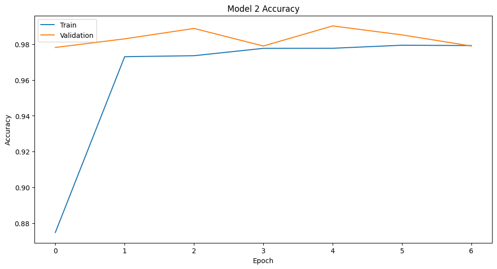

```python
# Plot training & validation accuracy values
plt.figure(figsize=(12, 6))

N = len(Model_2_history.history["accuracy"])

plt.plot(np.arange(0, N),Model_2_history.history['accuracy'], label='Train Accuracy')
plt.plot(np.arange(0, N),Model_2_history.history['val_accuracy'], label='Validation Accuracy')
plt.title('Model 2 Accuracy')
plt.xlabel('Epoch')
plt.ylabel('Accuracy')
plt.legend(['Train', 'Validation'], loc='upper left')

plt.show()
```

#### **Plotting the confusion matrix**

```
82/82 ━━━━━━━━━━━━━━━━━━━━ 4s 45ms/step
              precision    recall  f1-score   support

           0       0.98      0.98      0.98      1300
           1       0.98      0.98      0.98      1300

    accuracy                           0.98      2600
   macro avg       0.98      0.98      0.98      2600
weighted avg       0.98      0.98      0.98      2600
```

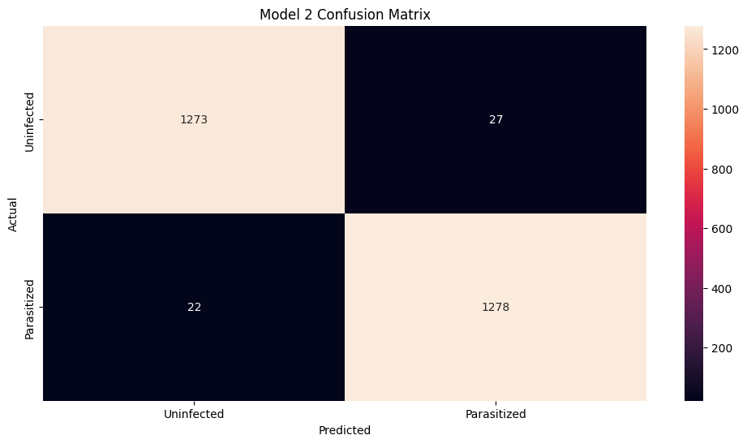

```python
# Make predictions on the test set using model_2
Model_2_pred = Model_2.predict(test_images)

# Convert the predicted probabilities to class labels
Model_2_pred = np.argmax(Model_2_pred, axis= 1)

# Convert one-hot encoded vectors to single labels for true test labels
True_class_labels_model2 = np.argmax(test_labels, axis= 1)

# Importing required functions
from sklearn.metrics import classification_report
from sklearn.metrics import confusion_matrix

# Printing the classification report
print(classification_report(True_class_labels_model2, Model_2_pred))

# Create the confusion matrix
confusion_matrix = tf.math.confusion_matrix(True_class_labels_model2, Model_2_pred)

# Ploting the heatmap using confusion matrix
plt.figure(figsize = (12, 6))
sns.heatmap(confusion_matrix, annot = True,  fmt = '.0f', xticklabels = ['Uninfected', 'Parasitized'], yticklabels = ['Uninfected', 'Parasitized'])
plt.title('Model 2 Confusion Matrix')
plt.xlabel('Predicted')
plt.ylabel('Actual')

plt.show()
```

#### **Observations:**

Model 2 is similar to the Base Model but with larger 3x3 kernels and a slightly higher parameter count designed to capture more detailed spatial features.

### **Models Comparison:**

- **Base-Model:** Shows the best generalization to test data with the highest test accuracy, although with a slightly higher loss and more balanced false positives and negatives.
- **Model-1:** Exhibits the highest training accuracy but the lowest test accuracy, suggesting potential overfitting, with a high number of false positives but fewer false negatives.
- **Model-2:** Provides a balance between the Base Model and Model 1, with intermediate training and test accuracy and a more balanced confusion matrix compared to Model 1.

## **Building Models using Data Augmentation**

Checking if the performance of the model can be improved by changing different parameters in the ImageDataGenerator.

```python
# Clearing back end
from tensorflow.keras import backend
backend.clear_session()

# Fixing the seed at 42 for random number generators
import random
np.random.seed(42)
random.seed(42)
tf.random.set_seed(42)
```

#### **Use image data generator**

```python
# import required libraries
from sklearn.model_selection import train_test_split
from tensorflow.keras.preprocessing.image import ImageDataGenerator

# Use the sklearn function to splits the dataset into training and validation sets
X_train, X_val, y_train, y_val = train_test_split(train_images, train_labels, test_size = 0.2, random_state = 42)

# use image data generator to create the data augmentation and expanding the size of the training dataset.
train_datagen = ImageDataGenerator(horizontal_flip=True,  # Randomly flip images horizontally.
                                   rotation_range=30,      # Randomly rotate images by up to 30 degrees.
                                   vertical_flip=True,    # Randomly flip images vertically.
                                   channel_shift_range=0.2,  # Randomly shift the colors.
                                   width_shift_range=0.2,  # Shift images horizontally by up to 20% of the width
                                   height_shift_range=0.2,  # Shift images vertically by up to 20% of the height
                                    )



val_datagen  = ImageDataGenerator()
# Flowing training images using train_datagen generator
train_generator = train_datagen.flow(x = X_train, y = y_train, batch_size = 32, seed = 42, shuffle = True)

# Flowing validation images using val_datagen generator
val_generator =  val_datagen.flow(x = X_val, y = y_val, batch_size = 32, seed = 42, shuffle = True)
```

#### **Visualizing Augmented images**

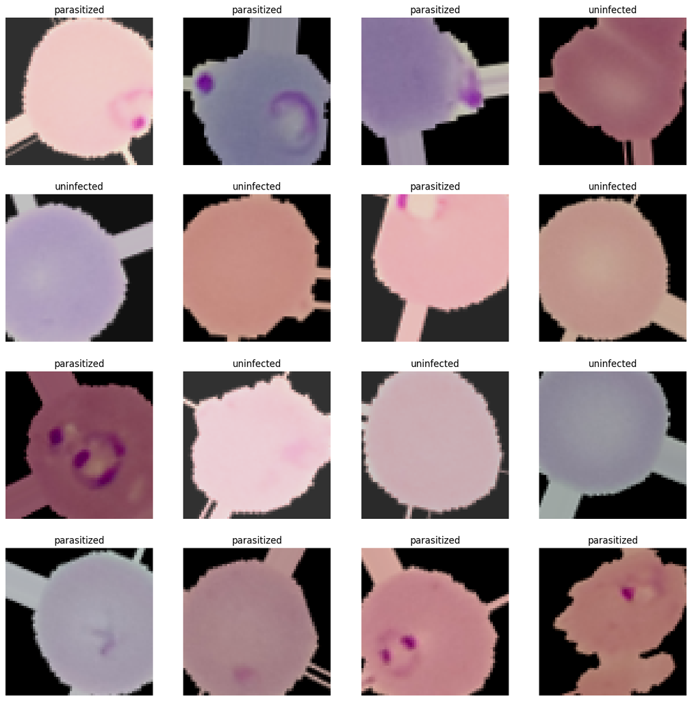

```python
# Creating an iterable for images and labels from the training data
images, labels = next(train_generator)

# Plotting 16 images from the training data
fig, axes = plt.subplots(4, 4, figsize = (16, 8))

fig.set_size_inches(16, 16)
for (image, label, ax) in zip(images, labels, axes.flatten()):

    ax.imshow(image)
    if label[1] == 1:
        ax.set_title('parasitized')
    else:
        ax.set_title('uninfected')

    ax.axis('off')
```

#### **Observations and Insights:**

- Rotation: The images appear to be rotated, as seen in the varying angles of the cells.
- Flipping: Both horizontal and vertical flipping are likely applied, given the variation in cell orientation.
- Color Shifts: There are noticeable changes in color across the images, which aligns with the use of the channel_shift_range parameter in the ImageDataGenerator.
- Translation: The cells appear to be shifted within the frame, consistent with the width_shift_range and height_shift_range parameters.
- Increased Variability: he augmentations introduce variations in the dataset, helping the model learn more robust features rather than overfitting to specific orientations or colors of cells. #####**Balanced Classes:**
- The augmentations are applied equally to both "parasitized" and "uninfected" cells, ensuring that both classes benefit from the increased variability.

### **Working on Improving the previous larger CNN architectures using Augmented Data For training:**

**Model 3 Augmented with data training:**

## Building **"Model-3"**

```python
# Clearing back end
from tensorflow.keras import backend
backend.clear_session()

# Fixing the seed at 42 for random number generators
import random
np.random.seed(42)
random.seed(42)
tf.random.set_seed(42)
```

```python
def Model_3():
    model = Sequential()

    # First Convolutional layer with kernel size of 3x3
    model.add(Conv2D(32, (3, 3), padding='same', activation='relu', input_shape=(64, 64, 3)))

    model.add(MaxPooling2D(pool_size=(2, 2)))
    model.add(Dropout(0.2))

    # Second Convolutional layer with kernel size of 3x3
    model.add(Conv2D(32, (3, 3), padding='same', activation='relu'))

    model.add(MaxPooling2D(pool_size=(2, 2)))
    model.add(Dropout(0.2))

    # Third Convolutional layer with kernel size of 3x3
    model.add(Conv2D(32, (3, 3), padding='same', activation='relu'))

    model.add(MaxPooling2D(pool_size=(2, 2)))
    model.add(Dropout(0.2))

    # Flatten the output from the previous layer
    model.add(Flatten())

    # Dense layer with 512 nodes, BatchNormalization, and 'relu' activation
    model.add(Dense(512, activation='relu'))

    model.add(Dropout(0.4))

    # Final output layer with 2 nodes and 'softmax' activation
    model.add(Dense(2, activation='softmax'))  # 2 represents output layer neurons

    # Compile the model
    model.compile(loss='binary_crossentropy', optimizer= 'adam', metrics=['accuracy'])

    return model
```

```python
# create Model 3 using the function and print its summary
Model_3 = Model_3()
Model_3.summary()
```

```
Model: "sequential"
```

```
┏━━━━━━━━━━━━━━━━━━━━━━━━━━━━━━━━━━━━━━┳━━━━━━━━━━━━━━━━━━━━━━━━━━━━━┳━━━━━━━━━━━━━━━━━┓
┃ Layer (type)                         ┃ Output Shape                ┃         Param # ┃
┡━━━━━━━━━━━━━━━━━━━━━━━━━━━━━━━━━━━━━━╇━━━━━━━━━━━━━━━━━━━━━━━━━━━━━╇━━━━━━━━━━━━━━━━━┩
│ conv2d (Conv2D)                      │ (None, 64, 64, 32)          │             896 │
├──────────────────────────────────────┼─────────────────────────────┼─────────────────┤
│ max_pooling2d (MaxPooling2D)         │ (None, 32, 32, 32)          │               0 │
├──────────────────────────────────────┼─────────────────────────────┼─────────────────┤
│ dropout (Dropout)                    │ (None, 32, 32, 32)          │               0 │
├──────────────────────────────────────┼─────────────────────────────┼─────────────────┤
│ conv2d_1 (Conv2D)                    │ (None, 32, 32, 32)          │           9,248 │
├──────────────────────────────────────┼─────────────────────────────┼─────────────────┤
│ max_pooling2d_1 (MaxPooling2D)       │ (None, 16, 16, 32)          │               0 │
├──────────────────────────────────────┼─────────────────────────────┼─────────────────┤
│ dropout_1 (Dropout)                  │ (None, 16, 16, 32)          │               0 │
├──────────────────────────────────────┼─────────────────────────────┼─────────────────┤
│ conv2d_2 (Conv2D)                    │ (None, 16, 16, 32)          │           9,248 │
├──────────────────────────────────────┼─────────────────────────────┼─────────────────┤
│ max_pooling2d_2 (MaxPooling2D)       │ (None, 8, 8, 32)            │               0 │
├──────────────────────────────────────┼─────────────────────────────┼─────────────────┤
│ dropout_2 (Dropout)                  │ (None, 8, 8, 32)            │               0 │
├──────────────────────────────────────┼─────────────────────────────┼─────────────────┤
│ flatten (Flatten)                    │ (None, 2048)                │               0 │
├──────────────────────────────────────┼─────────────────────────────┼─────────────────┤
│ dense (Dense)                        │ (None, 512)                 │       1,049,088 │
├──────────────────────────────────────┼─────────────────────────────┼─────────────────┤
│ dropout_3 (Dropout)                  │ (None, 512)                 │               0 │
├──────────────────────────────────────┼─────────────────────────────┼─────────────────┤
│ dense_1 (Dense)                      │ (None, 2)                   │           1,026 │
└──────────────────────────────────────┴─────────────────────────────┴─────────────────┘
```

```
 Total params: 1,069,506 (4.08 MB)
```

```
 Trainable params: 1,069,506 (4.08 MB)
```

```
 Non-trainable params: 0 (0.00 B)
```

#### **Using Callbacks**

```python
# Callbacks
callbacks = [
    EarlyStopping(monitor='val_loss', patience=5,),
    ModelCheckpoint('/content/drive/MyDrive/MIT/Projects/Capstone Project_Malaria Detection_Deep learning/Notebooks/call backs/Model_3.keras', monitor='val_loss', save_best_only=True),
]
```

#### **Fit and train the Model**

```python
Model_3_history = Model_3.fit( train_generator, validation_data =val_generator, epochs=20, callbacks=callbacks,verbose=1)
```

```
624/624 ━━━━━━━━━━━━━━━━━━━━ 148s 232ms/step - accuracy: 0.6940 - loss: 0.5387 - val_accuracy: 0.9728 - val_loss: 0.0886
624/624 ━━━━━━━━━━━━━━━━━━━━ 143s 229ms/step - accuracy: 0.9431 - loss: 0.1674 - val_accuracy: 0.9760 - val_loss: 0.0779
624/624 ━━━━━━━━━━━━━━━━━━━━ 141s 226ms/step - accuracy: 0.9515 - loss: 0.1440 - val_accuracy: 0.9806 - val_loss: 0.0665
624/624 ━━━━━━━━━━━━━━━━━━━━ 143s 227ms/step - accuracy: 0.9549 - loss: 0.1345 - val_accuracy: 0.9736 - val_loss: 0.0808
624/624 ━━━━━━━━━━━━━━━━━━━━ 141s 226ms/step - accuracy: 0.9568 - loss: 0.1348 - val_accuracy: 0.9790 - val_loss: 0.0712
624/624 ━━━━━━━━━━━━━━━━━━━━ 142s 227ms/step - accuracy: 0.9583 - loss: 0.1278 - val_accuracy: 0.9788 - val_loss: 0.0654
624/624 ━━━━━━━━━━━━━━━━━━━━ 143s 229ms/step - accuracy: 0.9599 - loss: 0.1254 - val_accuracy: 0.9778 - val_loss: 0.0742
624/624 ━━━━━━━━━━━━━━━━━━━━ 208s 240ms/step - accuracy: 0.9618 - loss: 0.1203 - val_accuracy: 0.9774 - val_loss: 0.0668
624/624 ━━━━━━━━━━━━━━━━━━━━ 197s 232ms/step - accuracy: 0.9600 - loss: 0.1225 - val_accuracy: 0.9788 - val_loss: 0.0656
624/624 ━━━━━━━━━━━━━━━━━━━━ 142s 227ms/step - accuracy: 0.9648 - loss: 0.1121 - val_accuracy: 0.9782 - val_loss: 0.0631
624/624 ━━━━━━━━━━━━━━━━━━━━ 145s 232ms/step - accuracy: 0.9631 - loss: 0.1178 - val_accuracy: 0.9800 - val_loss: 0.0657
624/624 ━━━━━━━━━━━━━━━━━━━━ 201s 231ms/step - accuracy: 0.9602 - loss: 0.1259 - val_accuracy: 0.9798 - val_loss: 0.0702
624/624 ━━━━━━━━━━━━━━━━━━━━ 144s 231ms/step - accuracy: 0.9638 - loss: 0.1159 - val_accuracy: 0.9818 - val_loss: 0.0566
624/624 ━━━━━━━━━━━━━━━━━━━━ 143s 229ms/step - accuracy: 0.9615 - loss: 0.1216 - val_accuracy: 0.9802 - val_loss: 0.0632
624/624 ━━━━━━━━━━━━━━━━━━━━ 145s 232ms/step - accuracy: 0.9627 - loss: 0.1155 - val_accuracy: 0.9798 - val_loss: 0.0635
624/624 ━━━━━━━━━━━━━━━━━━━━ 197s 224ms/step - accuracy: 0.9623 - loss: 0.1157 - val_accuracy: 0.9788 - val_loss: 0.0627
624/624 ━━━━━━━━━━━━━━━━━━━━ 140s 224ms/step - accuracy: 0.9670 - loss: 0.1053 - val_accuracy: 0.9786 - val_loss: 0.0660
624/624 ━━━━━━━━━━━━━━━━━━━━ 142s 224ms/step - accuracy: 0.9634 - loss: 0.1069 - val_accuracy: 0.9804 - val_loss: 0.0604
```

#### **Evaluating Model-3 on test data**

```python
# Evaluate the model
loss_model_3, accuracy_model_3 = Model_3.evaluate(test_images, test_labels, verbose=1)

# Print the loss and accuracy
print('Test Loss:', loss_model_3)
print('Test Accuracy:', accuracy_model_3)
```

```
82/82 ━━━━━━━━━━━━━━━━━━━━ 7s 84ms/step - accuracy: 0.9829 - loss: 0.0462
Test Loss: 0.04708850383758545
Test Accuracy: 0.982692301273346
```

#### **Plotting the train and validation curves**

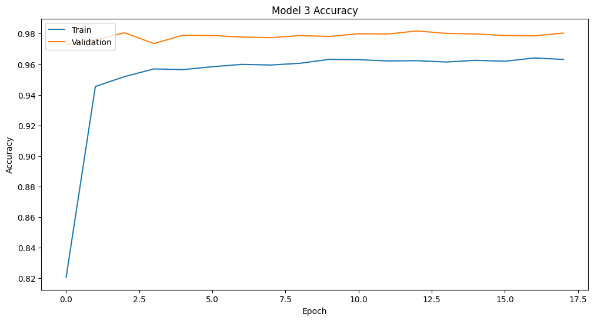

```python
# Plot training & validation accuracy values
plt.figure(figsize=(12, 6))

N = len(Model_3_history.history["accuracy"])

plt.plot(np.arange(0, N),Model_3_history.history['accuracy'], label='Train Accuracy')
plt.plot(np.arange(0, N),Model_3_history.history['val_accuracy'], label='Validation Accuracy')
plt.title('Model 3 Accuracy')
plt.xlabel('Epoch')
plt.ylabel('Accuracy')
plt.legend(['Train', 'Validation'], loc='upper left')

plt.show()
```

#### **Plotting the confusion matrix**

```
82/82 ━━━━━━━━━━━━━━━━━━━━ 3s 40ms/step
              precision    recall  f1-score   support

           0       0.98      0.99      0.98      1300
           1       0.99      0.98      0.98      1300

    accuracy                           0.98      2600
   macro avg       0.98      0.98      0.98      2600
weighted avg       0.98      0.98      0.98      2600
```

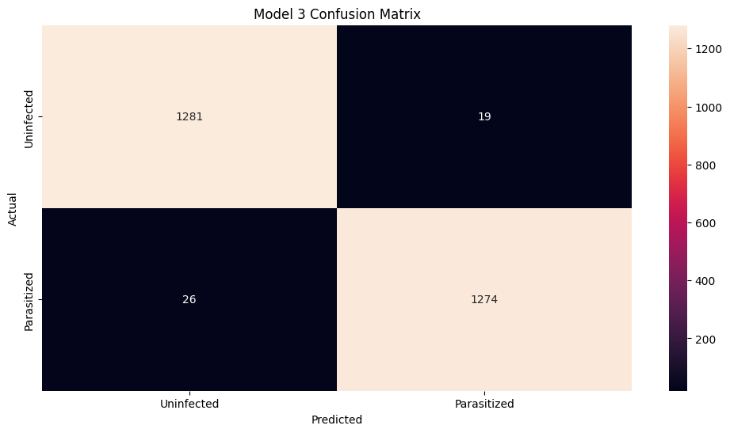

```python
# Make predictions on the test set using model 3
Model_3_pred = Model_3.predict(test_images)

# Convert the predicted probabilities to class labels
Model_3_pred = np.argmax(Model_3_pred, axis= 1)

# Convert one-hot encoded vectors to single labels for true test labels
True_class_labels_model3 = np.argmax(test_labels, axis= 1)

# Importing required functions
from sklearn.metrics import classification_report
from sklearn.metrics import confusion_matrix

# Printing the classification report
print(classification_report(True_class_labels_model3, Model_3_pred))

# Create the confusion matrix
confusion_matrix = tf.math.confusion_matrix(True_class_labels_model3, Model_3_pred)

# Ploting the heatmap using confusion matrix
plt.figure(figsize = (12, 6))
sns.heatmap(confusion_matrix, annot = True,  fmt = '.0f', xticklabels = ['Uninfected', 'Parasitized'], yticklabels = ['Uninfected', 'Parasitized'])
plt.title('Model 3 Confusion Matrix')
plt.xlabel('Predicted')
plt.ylabel('Actual')

plt.show()
```

#### **Observations:**

Comparing to Model 2 that has similar architecture the Model 3 been trained on augmented data demonstrates strong generalization with a high test accuracy and well-balanced performance metrics.

## Building **"Model-4"**

```python
# Clearing back end
from tensorflow.keras import backend
backend.clear_session()

# Fixing the seed at 42 for random number generators
import random
np.random.seed(42)
random.seed(42)
tf.random.set_seed(42)
```

```python
def Model_4():
    model = Sequential()

    # First Convolutional layer
    model.add(Conv2D(32, (3, 3), padding='same',input_shape=(64, 64, 3)))
    model.add(LeakyReLU(alpha=0.1))
    model.add(BatchNormalization())
    model.add(MaxPooling2D(pool_size=(2, 2)))

    # First Convolutional layer
    model.add(Conv2D(32, (3, 3), padding='same'))
    model.add(LeakyReLU(alpha=0.1))
    model.add(BatchNormalization())
    model.add(MaxPooling2D(pool_size=(2, 2)))


    # Second Convolutional layer
    model.add(Conv2D(64, (3, 3), padding='same'))
    model.add(LeakyReLU(alpha=0.1))
    model.add(BatchNormalization())
    model.add(MaxPooling2D(pool_size=(2, 2)))

    # Second Convolutional layer
    model.add(Conv2D(64, (3, 3), padding='same'))
    model.add(LeakyReLU(alpha=0.1))
    model.add(BatchNormalization())
    model.add(MaxPooling2D(pool_size=(2, 2)))


    # Third Convolutional layer
    model.add(Conv2D(128, (3, 3), padding='same'))
    model.add(LeakyReLU(alpha=0.1))
    model.add(BatchNormalization())
    model.add(MaxPooling2D(pool_size=(2, 2)))

    # Third Convolutional layer
    model.add(Conv2D(128, (3, 3), padding='same'))
    model.add(LeakyReLU(alpha=0.1))
    model.add(BatchNormalization())
    model.add(MaxPooling2D(pool_size=(2, 2)))

    # Flatten the output
    model.add(Flatten())

    # Dense layer with ReLU activation
    model.add(Dense(1024, activation='relu'))
    model.add(Dropout(0.3))

    # Dense layer with ReLU activation
    model.add(Dense(512, activation='relu'))

    # Final output layer
    model.add(Dense(2, activation='softmax'))


    # Compile the model
    model.compile(loss='binary_crossentropy',optimizer=Adam(learning_rate=0.001), metrics=['accuracy'])

    return model
```

```python
# create Model 4 using the function and print its summary
Model_4 = Model_4()
Model_4.summary()
```

```
Model: "sequential"
```

```
┏━━━━━━━━━━━━━━━━━━━━━━━━━━━━━━━━━━━━━━┳━━━━━━━━━━━━━━━━━━━━━━━━━━━━━┳━━━━━━━━━━━━━━━━━┓
┃ Layer (type)                         ┃ Output Shape                ┃         Param # ┃
┡━━━━━━━━━━━━━━━━━━━━━━━━━━━━━━━━━━━━━━╇━━━━━━━━━━━━━━━━━━━━━━━━━━━━━╇━━━━━━━━━━━━━━━━━┩
│ conv2d (Conv2D)                      │ (None, 64, 64, 32)          │             896 │
├──────────────────────────────────────┼─────────────────────────────┼─────────────────┤
│ leaky_re_lu (LeakyReLU)              │ (None, 64, 64, 32)          │               0 │
├──────────────────────────────────────┼─────────────────────────────┼─────────────────┤
│ batch_normalization                  │ (None, 64, 64, 32)          │             128 │
│ (BatchNormalization)                 │                             │                 │
├──────────────────────────────────────┼─────────────────────────────┼─────────────────┤
│ max_pooling2d (MaxPooling2D)         │ (None, 32, 32, 32)          │               0 │
├──────────────────────────────────────┼─────────────────────────────┼─────────────────┤
│ conv2d_1 (Conv2D)                    │ (None, 32, 32, 32)          │           9,248 │
├──────────────────────────────────────┼─────────────────────────────┼─────────────────┤
│ leaky_re_lu_1 (LeakyReLU)            │ (None, 32, 32, 32)          │               0 │
├──────────────────────────────────────┼─────────────────────────────┼─────────────────┤
│ batch_normalization_1                │ (None, 32, 32, 32)          │             128 │
│ (BatchNormalization)                 │                             │                 │
├──────────────────────────────────────┼─────────────────────────────┼─────────────────┤
│ max_pooling2d_1 (MaxPooling2D)       │ (None, 16, 16, 32)          │               0 │
├──────────────────────────────────────┼─────────────────────────────┼─────────────────┤
│ conv2d_2 (Conv2D)                    │ (None, 16, 16, 64)          │          18,496 │
├──────────────────────────────────────┼─────────────────────────────┼─────────────────┤
│ leaky_re_lu_2 (LeakyReLU)            │ (None, 16, 16, 64)          │               0 │
├──────────────────────────────────────┼─────────────────────────────┼─────────────────┤
│ batch_normalization_2                │ (None, 16, 16, 64)          │             256 │
│ (BatchNormalization)                 │                             │                 │
├──────────────────────────────────────┼─────────────────────────────┼─────────────────┤
│ max_pooling2d_2 (MaxPooling2D)       │ (None, 8, 8, 64)            │               0 │
├──────────────────────────────────────┼─────────────────────────────┼─────────────────┤
│ conv2d_3 (Conv2D)                    │ (None, 8, 8, 64)            │          36,928 │
├──────────────────────────────────────┼─────────────────────────────┼─────────────────┤
│ leaky_re_lu_3 (LeakyReLU)            │ (None, 8, 8, 64)            │               0 │
├──────────────────────────────────────┼─────────────────────────────┼─────────────────┤
│ batch_normalization_3                │ (None, 8, 8, 64)            │             256 │
│ (BatchNormalization)                 │                             │                 │
├──────────────────────────────────────┼─────────────────────────────┼─────────────────┤
│ max_pooling2d_3 (MaxPooling2D)       │ (None, 4, 4, 64)            │               0 │
├──────────────────────────────────────┼─────────────────────────────┼─────────────────┤
│ conv2d_4 (Conv2D)                    │ (None, 4, 4, 128)           │          73,856 │
```

[output cut: 12 more lines]

```
│ batch_normalization_5                │ (None, 2, 2, 128)           │             512 │
│ (BatchNormalization)                 │                             │                 │
├──────────────────────────────────────┼─────────────────────────────┼─────────────────┤
│ max_pooling2d_5 (MaxPooling2D)       │ (None, 1, 1, 128)           │               0 │
├──────────────────────────────────────┼─────────────────────────────┼─────────────────┤
│ flatten (Flatten)                    │ (None, 128)                 │               0 │
├──────────────────────────────────────┼─────────────────────────────┼─────────────────┤
│ dense (Dense)                        │ (None, 1024)                │         132,096 │
├──────────────────────────────────────┼─────────────────────────────┼─────────────────┤
│ dropout (Dropout)                    │ (None, 1024)                │               0 │
├──────────────────────────────────────┼─────────────────────────────┼─────────────────┤
│ dense_1 (Dense)                      │ (None, 512)                 │         524,800 │
├──────────────────────────────────────┼─────────────────────────────┼─────────────────┤
│ dense_2 (Dense)                      │ (None, 2)                   │           1,026 │
└──────────────────────────────────────┴─────────────────────────────┴─────────────────┘
```

```
 Total params: 946,722 (3.61 MB)
```

```
 Trainable params: 945,826 (3.61 MB)
```

```
 Non-trainable params: 896 (3.50 KB)
```

#### **Using Callbacks**

```python
# Callbacks
callbacks = [
    EarlyStopping(monitor='val_loss', patience=7),
    ModelCheckpoint('/content/drive/MyDrive/MIT/Projects/Capstone Project_Malaria Detection_Deep learning/Notebooks/call backs/My_Model_4.keras', monitor='val_loss', save_best_only=True),
]
```

#### **Fit and train the Model**

```python
Model_4_history = Model_4.fit( train_generator, validation_data = val_generator, epochs=20, callbacks=callbacks,verbose=1)
```

```
624/624 ━━━━━━━━━━━━━━━━━━━━ 226s 353ms/step - accuracy: 0.8245 - loss: 0.3667 - val_accuracy: 0.9619 - val_loss: 0.1297
624/624 ━━━━━━━━━━━━━━━━━━━━ 215s 344ms/step - accuracy: 0.9571 - loss: 0.1377 - val_accuracy: 0.9796 - val_loss: 0.0646
624/624 ━━━━━━━━━━━━━━━━━━━━ 260s 341ms/step - accuracy: 0.9600 - loss: 0.1262 - val_accuracy: 0.9786 - val_loss: 0.0675
624/624 ━━━━━━━━━━━━━━━━━━━━ 260s 338ms/step - accuracy: 0.9650 - loss: 0.1129 - val_accuracy: 0.9766 - val_loss: 0.0793
624/624 ━━━━━━━━━━━━━━━━━━━━ 215s 343ms/step - accuracy: 0.9620 - loss: 0.1149 - val_accuracy: 0.9762 - val_loss: 0.0613
624/624 ━━━━━━━━━━━━━━━━━━━━ 217s 347ms/step - accuracy: 0.9603 - loss: 0.1178 - val_accuracy: 0.9788 - val_loss: 0.0644
624/624 ━━━━━━━━━━━━━━━━━━━━ 264s 351ms/step - accuracy: 0.9655 - loss: 0.1103 - val_accuracy: 0.9772 - val_loss: 0.0704
624/624 ━━━━━━━━━━━━━━━━━━━━ 261s 350ms/step - accuracy: 0.9648 - loss: 0.1031 - val_accuracy: 0.9790 - val_loss: 0.0575
624/624 ━━━━━━━━━━━━━━━━━━━━ 219s 351ms/step - accuracy: 0.9621 - loss: 0.1138 - val_accuracy: 0.9822 - val_loss: 0.0551
624/624 ━━━━━━━━━━━━━━━━━━━━ 258s 345ms/step - accuracy: 0.9637 - loss: 0.1130 - val_accuracy: 0.9792 - val_loss: 0.0561
624/624 ━━━━━━━━━━━━━━━━━━━━ 226s 361ms/step - accuracy: 0.9664 - loss: 0.1122 - val_accuracy: 0.9814 - val_loss: 0.0586
624/624 ━━━━━━━━━━━━━━━━━━━━ 215s 344ms/step - accuracy: 0.9654 - loss: 0.1071 - val_accuracy: 0.9617 - val_loss: 0.1058
624/624 ━━━━━━━━━━━━━━━━━━━━ 217s 348ms/step - accuracy: 0.9685 - loss: 0.0956 - val_accuracy: 0.9752 - val_loss: 0.0743
624/624 ━━━━━━━━━━━━━━━━━━━━ 215s 344ms/step - accuracy: 0.9669 - loss: 0.0996 - val_accuracy: 0.9762 - val_loss: 0.0645
624/624 ━━━━━━━━━━━━━━━━━━━━ 265s 349ms/step - accuracy: 0.9674 - loss: 0.1007 - val_accuracy: 0.9802 - val_loss: 0.0542
624/624 ━━━━━━━━━━━━━━━━━━━━ 218s 349ms/step - accuracy: 0.9679 - loss: 0.0953 - val_accuracy: 0.9790 - val_loss: 0.0559
624/624 ━━━━━━━━━━━━━━━━━━━━ 218s 348ms/step - accuracy: 0.9673 - loss: 0.0982 - val_accuracy: 0.9802 - val_loss: 0.0534
624/624 ━━━━━━━━━━━━━━━━━━━━ 257s 341ms/step - accuracy: 0.9688 - loss: 0.0976 - val_accuracy: 0.9766 - val_loss: 0.0640
624/624 ━━━━━━━━━━━━━━━━━━━━ 216s 345ms/step - accuracy: 0.9672 - loss: 0.0996 - val_accuracy: 0.9812 - val_loss: 0.0500
624/624 ━━━━━━━━━━━━━━━━━━━━ 268s 356ms/step - accuracy: 0.9684 - loss: 0.1000 - val_accuracy: 0.9800 - val_loss: 0.0575
```

#### **Evaluating Model-4 on test data**

```python
# Evaluate the model
loss_model_4, accuracy_model_4 = Model_4.evaluate(test_images, test_labels, verbose=1)

# Print the loss and accuracy
print('Test Loss:', loss_model_4)
print('Test Accuracy:', accuracy_model_4)
```

```
82/82 ━━━━━━━━━━━━━━━━━━━━ 9s 91ms/step - accuracy: 0.9891 - loss: 0.0461
Test Loss: 0.046872109174728394
Test Accuracy: 0.9853846430778503
```

#### **Plotting the train and validation curves**

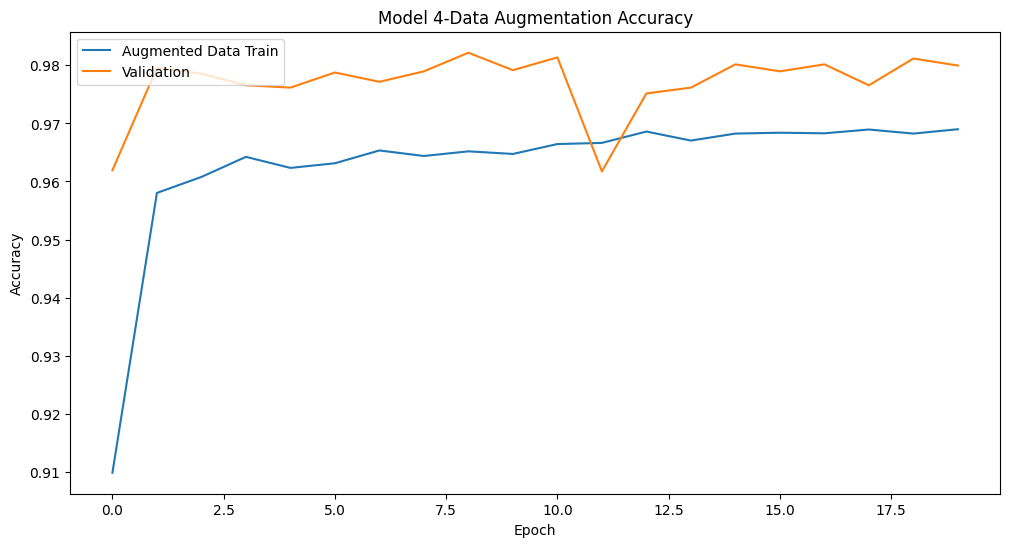

```python
# Plot training & validation accuracy values
plt.figure(figsize=(12, 6))

N = len(Model_4_history.history["accuracy"])

plt.plot(np.arange(0, N),Model_4_history.history['accuracy'], label='Train Accuracy')
plt.plot(np.arange(0, N),Model_4_history.history['val_accuracy'], label='Validation Accuracy')
plt.title('Model 4-Data Augmentation Accuracy')
plt.xlabel('Epoch')
plt.ylabel('Accuracy')
plt.legend(['Augmented Data Train', 'Validation'], loc='upper left')

plt.show()
```

#### **Plotting the confusion matrix**

```
82/82 ━━━━━━━━━━━━━━━━━━━━ 7s 89ms/step
              precision    recall  f1-score   support

           0       0.99      0.98      0.99      1300
           1       0.98      0.99      0.99      1300

    accuracy                           0.99      2600
   macro avg       0.99      0.99      0.99      2600
weighted avg       0.99      0.99      0.99      2600
```

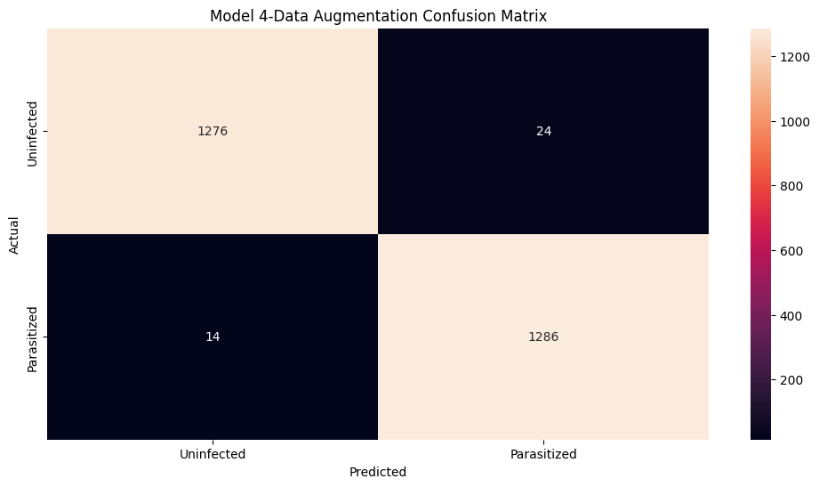

```python
# Make predictions on the test set using Model 4
Model_4_pred = Model_4.predict(test_images)

# Convert the predicted probabilities to class labels
Model_4_pred = np.argmax(Model_4_pred, axis= 1)

# Convert one-hot encoded vectors to single labels for true test labels
True_class_labels_model4 = np.argmax(test_labels, axis= 1)

# Importing required functions
from sklearn.metrics import classification_report
from sklearn.metrics import confusion_matrix

# Printing the classification report
print(classification_report(True_class_labels_model4, Model_4_pred  ))

# Create the confusion matrix
confusion_matrix = tf.math.confusion_matrix(True_class_labels_model4, Model_4_pred )

# Ploting the heatmap using confusion matrix
plt.figure(figsize = (12, 6))
sns.heatmap(confusion_matrix, annot = True,  fmt = '.0f', xticklabels = ['Uninfected', 'Parasitized'], yticklabels = ['Uninfected', 'Parasitized'])
plt.title('Model 4-Data Augmentation Confusion Matrix')
plt.xlabel('Predicted')
plt.ylabel('Actual')

plt.show()
```

#### **Observations:**

Since Model 4 has the same architecture as Model 1 but was trained with data augmentation, it's insightful to compare the impact of the augmented data on the model's performance.

## **Let's try to use Pretrained models with Transfer Learning and check how they will perform.**

## **Pre-trained model (VGG16)**

- Import VGG16 network upto any layer you choose
- Add Fully Connected Layers on top of it

```python
# Clear backend
from tensorflow.keras import backend
backend.clear_session()

# Fixing the seed for random number generators
np.random.seed(42)
import random
random.seed(42)
tf.random.set_seed(42)
```

#### **Load the VGG16 model**

```python
# Model enables the construction of complex models with multiple inputs and outputs and shared layers.
from tensorflow.keras.models import Model
# Import necessary libraries
from tensorflow.keras.applications.vgg16 import VGG16
```

```python
# Load VGG16 model without the top layers
vgg = VGG16(include_top=False, weights='imagenet', input_shape=(64, 64, 3))
vgg.summary()
```

```
Model: "vgg16"
```

```
┏━━━━━━━━━━━━━━━━━━━━━━━━━━━━━━━━━━━━━━┳━━━━━━━━━━━━━━━━━━━━━━━━━━━━━┳━━━━━━━━━━━━━━━━━┓
┃ Layer (type)                         ┃ Output Shape                ┃         Param # ┃
┡━━━━━━━━━━━━━━━━━━━━━━━━━━━━━━━━━━━━━━╇━━━━━━━━━━━━━━━━━━━━━━━━━━━━━╇━━━━━━━━━━━━━━━━━┩
│ input_layer (InputLayer)             │ (None, 64, 64, 3)           │               0 │
├──────────────────────────────────────┼─────────────────────────────┼─────────────────┤
│ block1_conv1 (Conv2D)                │ (None, 64, 64, 64)          │           1,792 │
├──────────────────────────────────────┼─────────────────────────────┼─────────────────┤
│ block1_conv2 (Conv2D)                │ (None, 64, 64, 64)          │          36,928 │
├──────────────────────────────────────┼─────────────────────────────┼─────────────────┤
│ block1_pool (MaxPooling2D)           │ (None, 32, 32, 64)          │               0 │
├──────────────────────────────────────┼─────────────────────────────┼─────────────────┤
│ block2_conv1 (Conv2D)                │ (None, 32, 32, 128)         │          73,856 │
├──────────────────────────────────────┼─────────────────────────────┼─────────────────┤
│ block2_conv2 (Conv2D)                │ (None, 32, 32, 128)         │         147,584 │
├──────────────────────────────────────┼─────────────────────────────┼─────────────────┤
│ block2_pool (MaxPooling2D)           │ (None, 16, 16, 128)         │               0 │
├──────────────────────────────────────┼─────────────────────────────┼─────────────────┤
│ block3_conv1 (Conv2D)                │ (None, 16, 16, 256)         │         295,168 │
├──────────────────────────────────────┼─────────────────────────────┼─────────────────┤
│ block3_conv2 (Conv2D)                │ (None, 16, 16, 256)         │         590,080 │
├──────────────────────────────────────┼─────────────────────────────┼─────────────────┤
│ block3_conv3 (Conv2D)                │ (None, 16, 16, 256)         │         590,080 │
├──────────────────────────────────────┼─────────────────────────────┼─────────────────┤
│ block3_pool (MaxPooling2D)           │ (None, 8, 8, 256)           │               0 │
├──────────────────────────────────────┼─────────────────────────────┼─────────────────┤
│ block4_conv1 (Conv2D)                │ (None, 8, 8, 512)           │       1,180,160 │
├──────────────────────────────────────┼─────────────────────────────┼─────────────────┤
│ block4_conv2 (Conv2D)                │ (None, 8, 8, 512)           │       2,359,808 │
├──────────────────────────────────────┼─────────────────────────────┼─────────────────┤
│ block4_conv3 (Conv2D)                │ (None, 8, 8, 512)           │       2,359,808 │
├──────────────────────────────────────┼─────────────────────────────┼─────────────────┤
│ block4_pool (MaxPooling2D)           │ (None, 4, 4, 512)           │               0 │
├──────────────────────────────────────┼─────────────────────────────┼─────────────────┤
│ block5_conv1 (Conv2D)                │ (None, 4, 4, 512)           │       2,359,808 │
├──────────────────────────────────────┼─────────────────────────────┼─────────────────┤
│ block5_conv2 (Conv2D)                │ (None, 4, 4, 512)           │       2,359,808 │
├──────────────────────────────────────┼─────────────────────────────┼─────────────────┤
│ block5_conv3 (Conv2D)                │ (None, 4, 4, 512)           │       2,359,808 │
├──────────────────────────────────────┼─────────────────────────────┼─────────────────┤
│ block5_pool (MaxPooling2D)           │ (None, 2, 2, 512)           │               0 │
└──────────────────────────────────────┴─────────────────────────────┴─────────────────┘
```

```
 Total params: 14,714,688 (56.13 MB)
```

```
 Trainable params: 14,714,688 (56.13 MB)
```

```
 Non-trainable params: 0 (0.00 B)
```

#### **Adding Fully Connected Layers on top of it**

```python
# Get the output of the last convolutional block from vgg16
transfer_layer = vgg.get_layer('block5_pool')
vgg.trainable = False

# Add layers on top
x = Flatten()(transfer_layer.output)

x = Dense(256, activation='relu')(x)
x = Dropout(0.3)(x)

x = Dense(128, activation='relu')(x)
x = Dropout(0.3)(x)

x = Dense(64, activation='relu')(x)
x = BatchNormalization()(x)

pred = Dense(2, activation='softmax')(x)

# Initialize the model
Model_based_vgg16 = Model(vgg.input, pred)


# Compile the model
Model_based_vgg16.compile(optimizer=Adam(learning_rate=0.001), loss='binary_crossentropy', metrics=['accuracy'])
```

#### **Using Callbacks**

```python
# Callbacks
callbacks = [
    EarlyStopping(monitor='val_loss', patience=2,),
    ModelCheckpoint('/content/drive/MyDrive/MIT/Projects/Capstone Project_Malaria Detection_Deep learning/Notebooks/call backs/Model_based_vgg16.keras', monitor='val_loss', save_best_only=True),]
```

#### **Fit and train the Model**

```python
# Fit the model
Model_based_vgg16_history = Model_based_vgg16.fit(train_images, train_labels, epochs=20, callbacks=callbacks ,batch_size=32, validation_split=0.2, verbose=1)
```

```
624/624 ━━━━━━━━━━━━━━━━━━━━ 1312s 2s/step - accuracy: 0.8303 - loss: 0.3791 - val_accuracy: 0.8844 - val_loss: 0.2973
624/624 ━━━━━━━━━━━━━━━━━━━━ 1337s 2s/step - accuracy: 0.9172 - loss: 0.2133 - val_accuracy: 0.9437 - val_loss: 0.1447
624/624 ━━━━━━━━━━━━━━━━━━━━ 1372s 2s/step - accuracy: 0.9258 - loss: 0.1888 - val_accuracy: 0.9499 - val_loss: 0.2025
624/624 ━━━━━━━━━━━━━━━━━━━━ 1339s 2s/step - accuracy: 0.9313 - loss: 0.1778 - val_accuracy: 0.9483 - val_loss: 0.2160
```

#### **Evaluating the Model_based_vgg16 on test data**

```python
# Evaluate the model
loss_model_Model_based_vgg16, accuracy_model_Model_based_vgg16 = Model_based_vgg16.evaluate(test_images, test_labels, verbose=1)

# Print the loss and accuracy
print('Test Loss:', loss_model_Model_based_vgg16)
print('Test Accuracy:', accuracy_model_Model_based_vgg16)
```

```
82/82 ━━━━━━━━━━━━━━━━━━━━ 138s 2s/step - accuracy: 0.9520 - loss: 0.1227
Test Loss: 0.20230717957019806
Test Accuracy: 0.9319230914115906
```

#### **Generate the classification report and confusion matrix**

```
82/82 ━━━━━━━━━━━━━━━━━━━━ 137s 2s/step
              precision    recall  f1-score   support

           0       0.96      0.90      0.93      1300
           1       0.91      0.96      0.93      1300

    accuracy                           0.93      2600
   macro avg       0.93      0.93      0.93      2600
weighted avg       0.93      0.93      0.93      2600
```

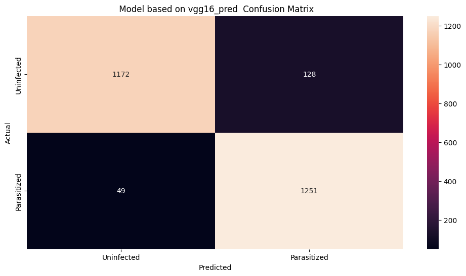

```python
# Make predictions on the test set using Model_based_vgg16
Model_based_vgg16_pred = Model_based_vgg16.predict(test_images)

# Convert the predicted probabilities to class labels
Model_based_vgg16_pred = np.argmax(Model_based_vgg16_pred, axis= 1)

# Convert one-hot encoded vectors to single labels for true test labels
True_class_labels_Model_based_vgg16_pred = np.argmax(test_labels, axis= 1)

# Importing required functions

from sklearn.metrics import classification_report
from sklearn.metrics import confusion_matrix

# Printing the classification report
print(classification_report(True_class_labels_Model_based_vgg16_pred, Model_based_vgg16_pred))

# Create the confusion matrix
confusion_matrix = tf.math.confusion_matrix(True_class_labels_Model_based_vgg16_pred, Model_based_vgg16_pred)

# Ploting the heatmap using confusion matrix
plt.figure(figsize = (12, 6))
sns.heatmap(confusion_matrix, annot = True,  fmt = '.0f', xticklabels = ['Uninfected', 'Parasitized'], yticklabels = ['Uninfected', 'Parasitized'])
plt.title(' Model based on vgg16_pred  Confusion Matrix')
plt.xlabel('Predicted')
plt.ylabel('Actual')

plt.show()
```

#### **Observations:**

VGG16 Model uses the pre-trained VGG16 architecture which is powerful but computationally costly.

## **Pre-trained model Efficientnet B2**

Let us try to use a pretrained model "Efficientnet B2" and check how it performs on our data.

- Import Efficientnet B2 network
- Lets add Fully Connected Layers on top of it

```python
# Specific model moduledesigned to prepare input images for use with EfficientNet models
from tensorflow.keras.applications.efficientnet import preprocess_input
# Import necessary modules
from tensorflow.keras.applications import EfficientNetB2
from tensorflow.keras.models import Model
```

```python
# Clear backend
from tensorflow.keras import backend
backend.clear_session()

# Fixing the seed for random number generators
np.random.seed(42)
import random
random.seed(42)
tf.random.set_seed(42)
```

#### **Load the Efficientnet B2 model**

For EfficientNet B2 to be able to process the data the normalized image have to be conveted back to a 0-255 range and ensures the data type is in float32 format.

```python
# conveted back the images to a 0-255 range and ensures the data type is float32.
ef_train_images = (train_images * 255).astype('float32')
ef_test_images = (test_images * 255).astype('float32')
```

```python
# Instantiate the EfficientNetB2 model
my_efficientnet_b2 = EfficientNetB2(weights='imagenet', include_top=False, input_shape=(64, 64, 3))

my_efficientnet_b2.summary()
```

```
Downloading data from https://storage.googleapis.com/keras-applications/efficientnetb2_notop.h5
31790344/31790344 ━━━━━━━━━━━━━━━━━━━━ 0s 0us/step
```

```
Model: "efficientnetb2"
```

```
┏━━━━━━━━━━━━━━━━━━━━━━━━━━━┳━━━━━━━━━━━━━━━━━━━━━━━━┳━━━━━━━━━━━━━━━━┳━━━━━━━━━━━━━━━━━━━━━━━━┓
┃ Layer (type)              ┃ Output Shape           ┃        Param # ┃ Connected to           ┃
┡━━━━━━━━━━━━━━━━━━━━━━━━━━━╇━━━━━━━━━━━━━━━━━━━━━━━━╇━━━━━━━━━━━━━━━━╇━━━━━━━━━━━━━━━━━━━━━━━━┩
│ input_layer (InputLayer)  │ (None, 64, 64, 3)      │              0 │ -                      │
├───────────────────────────┼────────────────────────┼────────────────┼────────────────────────┤
│ rescaling (Rescaling)     │ (None, 64, 64, 3)      │              0 │ input_layer[0][0]      │
├───────────────────────────┼────────────────────────┼────────────────┼────────────────────────┤
│ normalization             │ (None, 64, 64, 3)      │              7 │ rescaling[0][0]        │
│ (Normalization)           │                        │                │                        │
├───────────────────────────┼────────────────────────┼────────────────┼────────────────────────┤
│ rescaling_1 (Rescaling)   │ (None, 64, 64, 3)      │              0 │ normalization[0][0]    │
├───────────────────────────┼────────────────────────┼────────────────┼────────────────────────┤
│ stem_conv_pad             │ (None, 65, 65, 3)      │              0 │ rescaling_1[0][0]      │
│ (ZeroPadding2D)           │                        │                │                        │
├───────────────────────────┼────────────────────────┼────────────────┼────────────────────────┤
│ stem_conv (Conv2D)        │ (None, 32, 32, 32)     │            864 │ stem_conv_pad[0][0]    │
├───────────────────────────┼────────────────────────┼────────────────┼────────────────────────┤
│ stem_bn                   │ (None, 32, 32, 32)     │            128 │ stem_conv[0][0]        │
│ (BatchNormalization)      │                        │                │                        │
├───────────────────────────┼────────────────────────┼────────────────┼────────────────────────┤
│ stem_activation           │ (None, 32, 32, 32)     │              0 │ stem_bn[0][0]          │
│ (Activation)              │                        │                │                        │
├───────────────────────────┼────────────────────────┼────────────────┼────────────────────────┤
│ block1a_dwconv            │ (None, 32, 32, 32)     │            288 │ stem_activation[0][0]  │
│ (DepthwiseConv2D)         │                        │                │                        │
├───────────────────────────┼────────────────────────┼────────────────┼────────────────────────┤
│ block1a_bn                │ (None, 32, 32, 32)     │            128 │ block1a_dwconv[0][0]   │
│ (BatchNormalization)      │                        │                │                        │
├───────────────────────────┼────────────────────────┼────────────────┼────────────────────────┤
│ block1a_activation        │ (None, 32, 32, 32)     │              0 │ block1a_bn[0][0]       │
│ (Activation)              │                        │                │                        │
├───────────────────────────┼────────────────────────┼────────────────┼────────────────────────┤
│ block1a_se_squeeze        │ (None, 32)             │              0 │ block1a_activation[0]… │
│ (GlobalAveragePooling2D)  │                        │                │                        │
├───────────────────────────┼────────────────────────┼────────────────┼────────────────────────┤
│ block1a_se_reshape        │ (None, 1, 1, 32)       │              0 │ block1a_se_squeeze[0]… │
│ (Reshape)                 │                        │                │                        │
├───────────────────────────┼────────────────────────┼────────────────┼────────────────────────┤
│ block1a_se_reduce         │ (None, 1, 1, 8)        │            264 │ block1a_se_reshape[0]… │
│ (Conv2D)                  │                        │                │                        │
```

[output cut: 947 more lines]

```
│ (BatchNormalization)      │                        │                │                        │
├───────────────────────────┼────────────────────────┼────────────────┼────────────────────────┤
│ block7b_drop (Dropout)    │ (None, 2, 2, 352)      │              0 │ block7b_project_bn[0]… │
├───────────────────────────┼────────────────────────┼────────────────┼────────────────────────┤
│ block7b_add (Add)         │ (None, 2, 2, 352)      │              0 │ block7b_drop[0][0],    │
│                           │                        │                │ block7a_project_bn[0]… │
├───────────────────────────┼────────────────────────┼────────────────┼────────────────────────┤
│ top_conv (Conv2D)         │ (None, 2, 2, 1408)     │        495,616 │ block7b_add[0][0]      │
├───────────────────────────┼────────────────────────┼────────────────┼────────────────────────┤
│ top_bn                    │ (None, 2, 2, 1408)     │          5,632 │ top_conv[0][0]         │
│ (BatchNormalization)      │                        │                │                        │
├───────────────────────────┼────────────────────────┼────────────────┼────────────────────────┤
│ top_activation            │ (None, 2, 2, 1408)     │              0 │ top_bn[0][0]           │
│ (Activation)              │                        │                │                        │
└───────────────────────────┴────────────────────────┴────────────────┴────────────────────────┘
```

```
 Total params: 7,768,569 (29.63 MB)
```

```
 Trainable params: 7,700,994 (29.38 MB)
```

```
 Non-trainable params: 67,575 (263.97 KB)
```

#### **Adding Fully Connected Layers on top of it**

For EfficientNet B2 the GlobalAveragePooling2D is used before the fully connected dense layers to transition from the convolutional part of the network to the classification part which reduces the spatial dimensions of the input tensor to 1x1

```python
# Get the output of the last convolutional block
transfer_layer = my_efficientnet_b2.get_layer('top_activation').output
my_efficientnet_b2.trainable = False  # Freeze the EfficientNet B2 layers
```

```python
# It reduces the spatial dimensions of the input tensor to 1x1
from tensorflow.keras.layers import GlobalAveragePooling2D

# Add custom classification layers on top
x = GlobalAveragePooling2D()(transfer_layer)
x = BatchNormalization()(x)

x = Dense(256, activation='relu')(x)
x = Dropout(0.3)(x)

x = Dense(128, activation='relu')(x)
x = Dropout(0.3)(x)

x = Dense(64, activation='relu')(x)
x = Dropout(0.3)(x)

pred = Dense(2, activation='softmax')(x)

x = Dense(256, activation='relu')(x)
x = Dropout(0.3)(x)

x = Dense(128, activation='relu')(x)
x = Dropout(0.3)(x)

x = Dense(64, activation='relu')(x)
x = Dropout(0.3)(x)

pred = Dense(2, activation='softmax')(x)

# Initialize the model with the new name
my_model_efficientnet_b2 = Model(inputs=my_efficientnet_b2.input, outputs=pred)


# Compile the model
my_model_efficientnet_b2.compile(optimizer='adam', loss='binary_crossentropy', metrics=['accuracy'])
```

#### **Using Callbacks**

```python
# Callbacks
callbacks = [
    EarlyStopping(monitor='val_loss', patience=3),
    ModelCheckpoint('/content/drive/MyDrive/MIT/Projects/Capstone Project_Malaria Detection_Deep learning/Notebooks/call backs/My_model_efficientnet_b2.keras', monitor='val_loss', save_best_only=True)]
```

#### **Fit and train the Model**

```python
# Fit the model
my_model_efficientnet_b2_history = my_model_efficientnet_b2.fit(ef_train_images, train_labels, batch_size=32, epochs=30, validation_split=0.2, callbacks=callbacks, verbose=1)
```

```
624/624 ━━━━━━━━━━━━━━━━━━━━ 247s 362ms/step - accuracy: 0.8570 - loss: 0.3278 - val_accuracy: 0.9431 - val_loss: 0.1576
624/624 ━━━━━━━━━━━━━━━━━━━━ 262s 362ms/step - accuracy: 0.9286 - loss: 0.1937 - val_accuracy: 0.9541 - val_loss: 0.1224
624/624 ━━━━━━━━━━━━━━━━━━━━ 296s 416ms/step - accuracy: 0.9366 - loss: 0.1697 - val_accuracy: 0.9575 - val_loss: 0.1404
624/624 ━━━━━━━━━━━━━━━━━━━━ 264s 420ms/step - accuracy: 0.9350 - loss: 0.1737 - val_accuracy: 0.9597 - val_loss: 0.1323
624/624 ━━━━━━━━━━━━━━━━━━━━ 321s 419ms/step - accuracy: 0.9396 - loss: 0.1695 - val_accuracy: 0.9643 - val_loss: 0.1217
624/624 ━━━━━━━━━━━━━━━━━━━━ 220s 353ms/step - accuracy: 0.9433 - loss: 0.1582 - val_accuracy: 0.9631 - val_loss: 0.1244
624/624 ━━━━━━━━━━━━━━━━━━━━ 262s 354ms/step - accuracy: 0.9441 - loss: 0.1541 - val_accuracy: 0.9589 - val_loss: 0.1135
624/624 ━━━━━━━━━━━━━━━━━━━━ 265s 359ms/step - accuracy: 0.9460 - loss: 0.1494 - val_accuracy: 0.9615 - val_loss: 0.0998
624/624 ━━━━━━━━━━━━━━━━━━━━ 259s 355ms/step - accuracy: 0.9507 - loss: 0.1400 - val_accuracy: 0.9567 - val_loss: 0.1299
624/624 ━━━━━━━━━━━━━━━━━━━━ 258s 349ms/step - accuracy: 0.9477 - loss: 0.1440 - val_accuracy: 0.9583 - val_loss: 0.1147
624/624 ━━━━━━━━━━━━━━━━━━━━ 263s 351ms/step - accuracy: 0.9499 - loss: 0.1400 - val_accuracy: 0.9742 - val_loss: 0.0839
624/624 ━━━━━━━━━━━━━━━━━━━━ 261s 349ms/step - accuracy: 0.9501 - loss: 0.1382 - val_accuracy: 0.9665 - val_loss: 0.1060
624/624 ━━━━━━━━━━━━━━━━━━━━ 263s 351ms/step - accuracy: 0.9549 - loss: 0.1291 - val_accuracy: 0.9549 - val_loss: 0.1163
624/624 ━━━━━━━━━━━━━━━━━━━━ 263s 353ms/step - accuracy: 0.9529 - loss: 0.1358 - val_accuracy: 0.9663 - val_loss: 0.1112
```

#### **Evaluating the Model_based_Efficientnet_b2 on test data**

```python
# Evaluate the model
loss_Model_eff_b2, accuracy_Model__eff_b2 = my_model_efficientnet_b2.evaluate(ef_test_images, test_labels, verbose=1)

# Print the loss and accuracy
print('Test Loss:', loss_Model_eff_b2)
print('Test Accuracy:', accuracy_Model__eff_b2)
```

```
82/82 ━━━━━━━━━━━━━━━━━━━━ 26s 262ms/step - accuracy: 0.9592 - loss: 0.1053
Test Loss: 0.11645691841840744
Test Accuracy: 0.9596154093742371
```

#### **Plotting the train and validation curves**

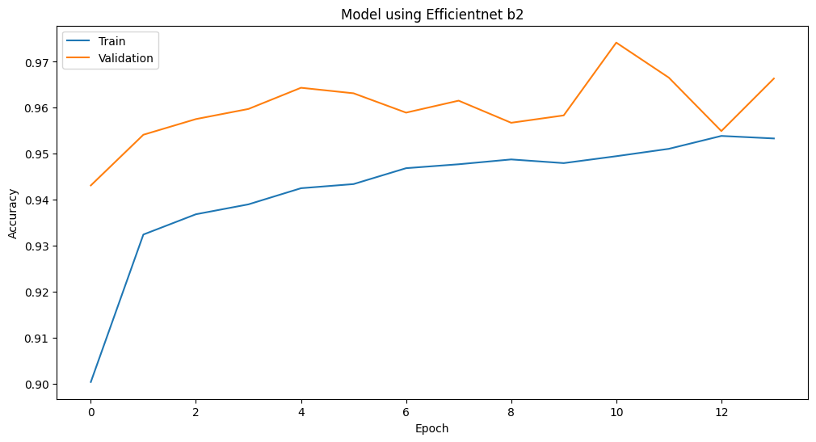

```python
# Plot training & validation accuracy values
plt.figure(figsize=(12, 6))

N = len(my_model_efficientnet_b2_history.history["accuracy"])

plt.plot(np.arange(0, N),my_model_efficientnet_b2_history.history['accuracy'], label='Train Accuracy')
plt.plot(np.arange(0, N),my_model_efficientnet_b2_history.history['val_accuracy'], label='Validation Accuracy')
plt.title('Model using Efficientnet b2')
plt.xlabel('Epoch')
plt.ylabel('Accuracy')
plt.legend(['Train', 'Validation'], loc='upper left')
plt.show()
```

#### **Plotting the confusion matrix**

```
82/82 ━━━━━━━━━━━━━━━━━━━━ 30s 305ms/step
              precision    recall  f1-score   support

           0       0.96      0.96      0.96      1300
           1       0.96      0.96      0.96      1300

    accuracy                           0.96      2600
   macro avg       0.96      0.96      0.96      2600
weighted avg       0.96      0.96      0.96      2600
```

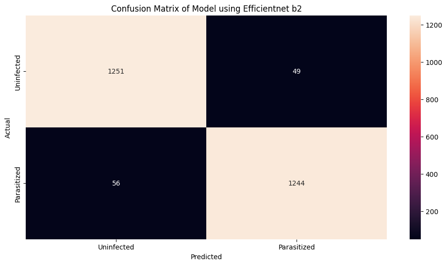

```python
# Make predictions on the test set using EfficientNet B2 model.
my_model_efficientnet_b2_pred = my_model_efficientnet_b2.predict(ef_test_images)

# Convert the predicted probabilities to class labels
my_model_efficientnet_b2_pred = np.argmax(my_model_efficientnet_b2_pred, axis= 1)

# Convert one-hot encoded vectors to single labels for true test labels
True_class_labels_my_model_efficientnet_b2 = np.argmax(test_labels, axis= 1)

# Importing required functions

from sklearn.metrics import classification_report
from sklearn.metrics import confusion_matrix

# Printing the classification report
print(classification_report(True_class_labels_my_model_efficientnet_b2, my_model_efficientnet_b2_pred ))

# Create the confusion matrix
confusion_matrix = tf.math.confusion_matrix(True_class_labels_my_model_efficientnet_b2, my_model_efficientnet_b2_pred)

# Ploting the heatmap using confusion matrix
plt.figure(figsize = (12, 6))
sns.heatmap(confusion_matrix, annot = True,  fmt = '.0f', xticklabels = ['Uninfected', 'Parasitized'], yticklabels = ['Uninfected', 'Parasitized'])
plt.title('Confusion Matrix of Model using Efficientnet b2')
plt.xlabel('Predicted')
plt.ylabel('Actual')

plt.show()
```

#### **Observations:**

EfficientNetB2 Model utilizes Global Average Pooling and several dense layers with dropout for regularization, balancing performance with a moderate parameter count.

## **Improved MobileNetV2 Model**

The model will use Global Average Pooling and "RMSprop Optimizer" (Root Mean Square Propagation) at its second fit.

```python
from tensorflow.keras.layers import GlobalAveragePooling2D
from tensorflow.keras.models import Model
from tensorflow.keras.applications import MobileNetV2
```

```python
# Clear backend
from tensorflow.keras import backend
backend.clear_session()

# Fixing the seed for random number generators
np.random.seed(42)
import random
random.seed(42)
tf.random.set_seed(42)
```

#### **Load the Model**

```python
# Load the MobileNetV2 model without the classification head
base_model = MobileNetV2(weights='imagenet', include_top=False, input_shape=(64, 64, 3))
```

```
Downloading data from https://storage.googleapis.com/tensorflow/keras-applications/mobilenet_v2/mobilenet_v2_weights_tf_dim_ordering_tf_kernels_1.0_224_no_top.h5
9406464/9406464 ━━━━━━━━━━━━━━━━━━━━ 1s 0us/step
```

**Adding Fully Connected Layers on top of it**

For Mobile Net V2 the GlobalAveragePooling2D is used before the fully connected dense layers to transition from the convolutional part of the network to the classification part which reduces the spatial dimensions of the input tensor to 1x1

#### **Fit and train the Model**

- Two fits are applied for this model:
- The Fit named history1 tracks the initial training phase.
- After that the fit named history2 tracks the model's performance throughout the fine-tuning phase.

```python
# Apply global average pooling to reduce the spatial dimensions
x = base_model.output
x = GlobalAveragePooling2D()(x)
x = Dropout(0.4)(x)
outputs = Dense(2, activation='softmax')(x)

# Create the final model
Improved_MobileNetV22 = Model(inputs=base_model.input, outputs=outputs)

# Freeze the base model
base_model.trainable = False

# Setup callbacks
callbacks = [
    EarlyStopping(patience=5, monitor='val_loss'),
    ModelCheckpoint('/content/drive/MyDrive/MIT/Projects/Capstone Project_Malaria Detection_Deep learning/Notebooks/call backs/TransLearning_MobileNetV2.keras', save_best_only=False)
]

# Compile the model
Improved_MobileNetV22.compile(optimizer= Adam(learning_rate=0.001), loss= 'categorical_crossentropy',metrics=['accuracy'])

# Train the model (feature extraction)
initial_epochs = 5
history1 = Improved_MobileNetV22.fit(train_images, train_labels,
                    batch_size=32,
                    epochs=initial_epochs,
                    validation_split=0.2,
                    callbacks=callbacks,
                    verbose=1)


# Unfreeze some layers of the base model for fine-tuning
base_model.trainable = True
fine_tune_at = 100

# Freeze all the layers before `fine_tune_at`
for layer in base_model.layers[:fine_tune_at]:
    layer.trainable = False

# Recompile the model with a lower learning rate for fine tuning
Improved_MobileNetV22.compile(loss= 'categorical_crossentropy', optimizer=tf.keras.optimizers.RMSprop(learning_rate=0.0001),metrics=['accuracy'])

# Continue training the model (fine-tuning)
fine_tune_epochs = 5
total_epochs = initial_epochs + fine_tune_epochs

history2 = Improved_MobileNetV22.fit(train_images, train_labels,
                         batch_size=32,
                         epochs=total_epochs, ## Train until the total number of epochs is reached
                         validation_split=0.2,
                         callbacks=callbacks,
                         initial_epoch=history1.epoch[-1],
                         verbose=1)
```

```
624/624 ━━━━━━━━━━━━━━━━━━━━ 92s 136ms/step - accuracy: 0.8687 - loss: 0.3262 - val_accuracy: 0.9095 - val_loss: 0.2532
624/624 ━━━━━━━━━━━━━━━━━━━━ 74s 119ms/step - accuracy: 0.9314 - loss: 0.1860 - val_accuracy: 0.9253 - val_loss: 0.2151
624/624 ━━━━━━━━━━━━━━━━━━━━ 91s 133ms/step - accuracy: 0.9342 - loss: 0.1763 - val_accuracy: 0.9283 - val_loss: 0.2057
624/624 ━━━━━━━━━━━━━━━━━━━━ 80s 128ms/step - accuracy: 0.9361 - loss: 0.1742 - val_accuracy: 0.9317 - val_loss: 0.1914
624/624 ━━━━━━━━━━━━━━━━━━━━ 75s 120ms/step - accuracy: 0.9343 - loss: 0.1734 - val_accuracy: 0.9305 - val_loss: 0.1956
624/624 ━━━━━━━━━━━━━━━━━━━━ 219s 317ms/step - accuracy: 0.8800 - loss: 0.4639 - val_accuracy: 0.9982 - val_loss: 0.0084
624/624 ━━━━━━━━━━━━━━━━━━━━ 175s 274ms/step - accuracy: 0.9616 - loss: 0.1280 - val_accuracy: 0.9968 - val_loss: 0.0109
624/624 ━━━━━━━━━━━━━━━━━━━━ 216s 296ms/step - accuracy: 0.9764 - loss: 0.0689 - val_accuracy: 0.9952 - val_loss: 0.0210
624/624 ━━━━━━━━━━━━━━━━━━━━ 225s 334ms/step - accuracy: 0.9863 - loss: 0.0390 - val_accuracy: 0.9936 - val_loss: 0.0474
624/624 ━━━━━━━━━━━━━━━━━━━━ 233s 288ms/step - accuracy: 0.9907 - loss: 0.0239 - val_accuracy: 0.9950 - val_loss: 0.0378
624/624 ━━━━━━━━━━━━━━━━━━━━ 225s 325ms/step - accuracy: 0.9949 - loss: 0.0154 - val_accuracy: 0.9810 - val_loss: 0.1753
```

#### **Evaluating the Improved MobileNetV2 Model on test data**

```python
# Evaluate the model
loss_Improved_MobileNetV2, accuracy_Improved_MobileNetV2 = Improved_MobileNetV22.evaluate(test_images, test_labels, verbose=1)

# Print the loss and accuracy
print('Test Loss:', loss_Improved_MobileNetV2)
print('Test Accuracy:', accuracy_Improved_MobileNetV2)
```

```
82/82 ━━━━━━━━━━━━━━━━━━━━ 13s 117ms/step - accuracy: 0.9678 - loss: 0.3813
Test Loss: 0.3078266680240631
Test Accuracy: 0.9700000286102295
```

#### **Plotting combined the train and validation curves**

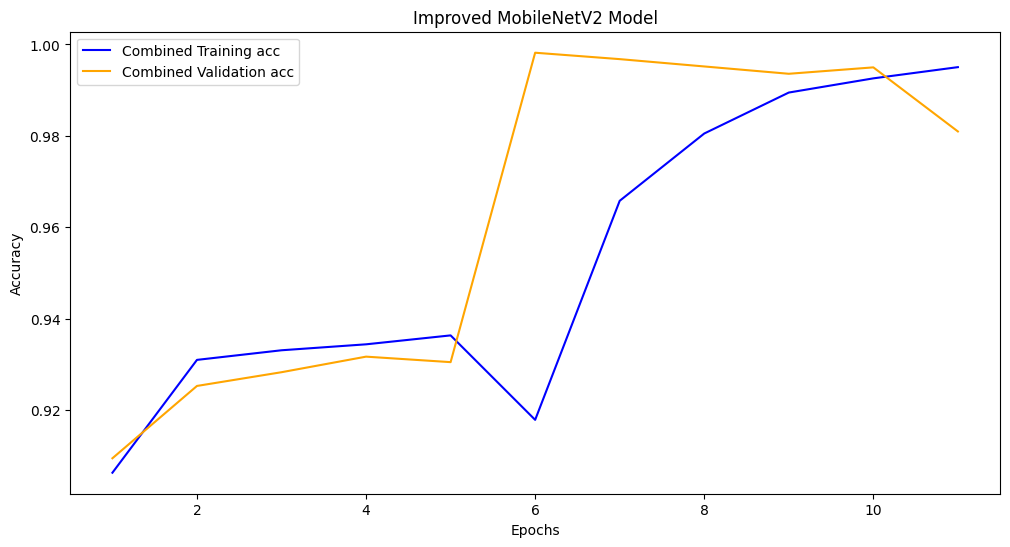

```python
# For history1 (5 epochs)
acc1 = history1.history['accuracy']
val_acc1 = history1.history['val_accuracy']

# For history2 (5 epochs)
acc2 = history2.history['accuracy']
val_acc2 = history2.history['val_accuracy']

# Concatenating the two histories
combined_acc = acc1 + acc2
combined_val_acc = val_acc1 + val_acc2

combined_epochs = range(1, len(combined_acc) + 1)

# Plotting accuracy
plt.figure(figsize=(12, 6))
plt.plot(combined_epochs, combined_acc, 'b', label='Combined Training acc')
plt.plot(combined_epochs, combined_val_acc, 'orange', label='Combined Validation acc')
plt.title('Improved MobileNetV2 Model')
plt.xlabel('Epochs')
plt.ylabel('Accuracy')
plt.legend()

plt.show()
```

#### **Plotting the confusion matrix**

```
82/82 ━━━━━━━━━━━━━━━━━━━━ 11s 114ms/step
              precision    recall  f1-score   support

           0       0.97      0.97      0.97      1300
           1       0.97      0.97      0.97      1300

    accuracy                           0.97      2600
   macro avg       0.97      0.97      0.97      2600
weighted avg       0.97      0.97      0.97      2600
```

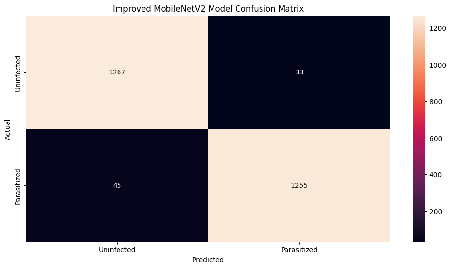

```python
# Make predictions on the test set using as a base Mobilenet_v2
Improved_MobileNetV22_pred = Improved_MobileNetV22.predict(test_images)

# Convert the predicted probabilities to class labels
Improved_MobileNetV22_pred = np.argmax(Improved_MobileNetV22_pred, axis= 1)

# Convert one-hot encoded vectors to single labels for true test labels
True_class_labels_Improved_MobileNetV22= np.argmax(test_labels, axis= 1)

# Importing required functions
from sklearn.metrics import classification_report
from sklearn.metrics import confusion_matrix

# Printing the classification report
print(classification_report(True_class_labels_Improved_MobileNetV22, Improved_MobileNetV22_pred ))

# Create the confusion matrix
confusion_matrix = tf.math.confusion_matrix(True_class_labels_Improved_MobileNetV22, Improved_MobileNetV22_pred  )

# Ploting the heatmap using confusion matrix
plt.figure(figsize = (12, 6))
sns.heatmap(confusion_matrix, annot = True,  fmt = '.0f', xticklabels = ['Uninfected', 'Parasitized'], yticklabels = ['Uninfected', 'Parasitized'])
plt.title('Improved MobileNetV2 Model Confusion Matrix')
plt.xlabel('Predicted')
plt.ylabel('Actual')

plt.show()
```

#### **Observations:**

MobileNetV2 Model employs the MobileNetV2 architecture, which is optimized for mobile and resource-constrained environments. The model includes fine-tuning after initial training, achieving strong generalization with the highest test accuracy.

### **Transfer Learning Models Comparison:**

- **VGG16 and EfficientNetB2** Models rely on fully connected layers to increase the models capacity but this comes with a higher risk of overfitting especially in VGG16. EfficientNetB2 mitigates this risk with better regularization.
- **MobileNetV2** Model demonstrates that fully connected layers are not always necessary for high performance. By using Global Average Pooling, MobileNetV2 achieves high accuracy with fewer parameters and better generalization, making it particularly suitable for applications where computational efficiency is critical.
- **Overall Recommendation:** In tasks where computational efficiency and generalization are critical architectures like MobileNetV2 which minimize or eliminate dense layers might be preferable. For more complex tasks requiring high capacity the balanced use of dense layers as seen in EfficientNetB2 can be beneficial but we must be careful to avoid overfitting.

## **Evaluate Model 4 with K-Fold Cross-Validation**

### **Observations and Conclusions drawn from the selected Model-4:**

Model 4 demonstrates the best overall performance among all models with the highest accuracy balanced classification and strong generalization. It outperforms the other Models in accuracy and misclassification rates making it the strongest choice for this classification task. Its Low computational requirements are making it the top model compared to all the tested Models among different architectures and Methodes.

```python
# Clear backend
from tensorflow.keras import backend
backend.clear_session()

# Fixing the seed for random number generators
np.random.seed(42)
import random
random.seed(42)
tf.random.set_seed(42)
```

#### **Load the pre-trained Model-4**

```python
# Load the model from the keras file
model4_cross = tf.keras.models.load_model('/content/drive/MyDrive/MIT/Projects/Capstone Project_Malaria Detection_Deep learning/Notebooks/call backs/My_Model_4.keras')

# Display the model architecture
model4_cross.summary()
```

```
Model: "sequential"
```

```
┏━━━━━━━━━━━━━━━━━━━━━━━━━━━━━━━━━━━━━━┳━━━━━━━━━━━━━━━━━━━━━━━━━━━━━┳━━━━━━━━━━━━━━━━━┓
┃ Layer (type)                         ┃ Output Shape                ┃         Param # ┃
┡━━━━━━━━━━━━━━━━━━━━━━━━━━━━━━━━━━━━━━╇━━━━━━━━━━━━━━━━━━━━━━━━━━━━━╇━━━━━━━━━━━━━━━━━┩
│ conv2d (Conv2D)                      │ (None, 64, 64, 32)          │             896 │
├──────────────────────────────────────┼─────────────────────────────┼─────────────────┤
│ leaky_re_lu (LeakyReLU)              │ (None, 64, 64, 32)          │               0 │
├──────────────────────────────────────┼─────────────────────────────┼─────────────────┤
│ batch_normalization                  │ (None, 64, 64, 32)          │             128 │
│ (BatchNormalization)                 │                             │                 │
├──────────────────────────────────────┼─────────────────────────────┼─────────────────┤
│ max_pooling2d (MaxPooling2D)         │ (None, 32, 32, 32)          │               0 │
├──────────────────────────────────────┼─────────────────────────────┼─────────────────┤
│ conv2d_1 (Conv2D)                    │ (None, 32, 32, 32)          │           9,248 │
├──────────────────────────────────────┼─────────────────────────────┼─────────────────┤
│ leaky_re_lu_1 (LeakyReLU)            │ (None, 32, 32, 32)          │               0 │
├──────────────────────────────────────┼─────────────────────────────┼─────────────────┤
│ batch_normalization_1                │ (None, 32, 32, 32)          │             128 │
│ (BatchNormalization)                 │                             │                 │
├──────────────────────────────────────┼─────────────────────────────┼─────────────────┤
│ max_pooling2d_1 (MaxPooling2D)       │ (None, 16, 16, 32)          │               0 │
├──────────────────────────────────────┼─────────────────────────────┼─────────────────┤
│ conv2d_2 (Conv2D)                    │ (None, 16, 16, 64)          │          18,496 │
├──────────────────────────────────────┼─────────────────────────────┼─────────────────┤
│ leaky_re_lu_2 (LeakyReLU)            │ (None, 16, 16, 64)          │               0 │
├──────────────────────────────────────┼─────────────────────────────┼─────────────────┤
│ batch_normalization_2                │ (None, 16, 16, 64)          │             256 │
│ (BatchNormalization)                 │                             │                 │
├──────────────────────────────────────┼─────────────────────────────┼─────────────────┤
│ max_pooling2d_2 (MaxPooling2D)       │ (None, 8, 8, 64)            │               0 │
├──────────────────────────────────────┼─────────────────────────────┼─────────────────┤
│ conv2d_3 (Conv2D)                    │ (None, 8, 8, 64)            │          36,928 │
├──────────────────────────────────────┼─────────────────────────────┼─────────────────┤
│ leaky_re_lu_3 (LeakyReLU)            │ (None, 8, 8, 64)            │               0 │
├──────────────────────────────────────┼─────────────────────────────┼─────────────────┤
│ batch_normalization_3                │ (None, 8, 8, 64)            │             256 │
│ (BatchNormalization)                 │                             │                 │
├──────────────────────────────────────┼─────────────────────────────┼─────────────────┤
│ max_pooling2d_3 (MaxPooling2D)       │ (None, 4, 4, 64)            │               0 │
├──────────────────────────────────────┼─────────────────────────────┼─────────────────┤
│ conv2d_4 (Conv2D)                    │ (None, 4, 4, 128)           │          73,856 │
```

[output cut: 12 more lines]

```
│ batch_normalization_5                │ (None, 2, 2, 128)           │             512 │
│ (BatchNormalization)                 │                             │                 │
├──────────────────────────────────────┼─────────────────────────────┼─────────────────┤
│ max_pooling2d_5 (MaxPooling2D)       │ (None, 1, 1, 128)           │               0 │
├──────────────────────────────────────┼─────────────────────────────┼─────────────────┤
│ flatten (Flatten)                    │ (None, 128)                 │               0 │
├──────────────────────────────────────┼─────────────────────────────┼─────────────────┤
│ dense (Dense)                        │ (None, 1024)                │         132,096 │
├──────────────────────────────────────┼─────────────────────────────┼─────────────────┤
│ dropout (Dropout)                    │ (None, 1024)                │               0 │
├──────────────────────────────────────┼─────────────────────────────┼─────────────────┤
│ dense_1 (Dense)                      │ (None, 512)                 │         524,800 │
├──────────────────────────────────────┼─────────────────────────────┼─────────────────┤
│ dense_2 (Dense)                      │ (None, 2)                   │           1,026 │
└──────────────────────────────────────┴─────────────────────────────┴─────────────────┘
```

```
 Total params: 2,838,376 (10.83 MB)
```

```
 Trainable params: 945,826 (3.61 MB)
```

```
 Non-trainable params: 896 (3.50 KB)
```

```
 Optimizer params: 1,891,654 (7.22 MB)
```

#### **Model-4 Cross-Validation on the Original Images**

```python
from sklearn.model_selection import KFold
import numpy as np

# Define the number of splits for cross-validation
kfold = KFold(n_splits=6, shuffle=True, random_state=42)

# Initialize lists to hold the accuracy and loss for each fold
acc_per_fold = []
loss_per_fold = []

# K-Fold Cross-Validation
fold_no = 1
for train_index, val_index in kfold.split(train_images):



    # Split the data into training and validation sets according to the indices provided by KFold
    x_train_orign, x_val_orign = train_images[train_index], train_images[val_index]
    y_train_orign, y_val_orign = train_labels[train_index], train_labels[val_index]

    # Evaluate the model (no retraining)
    scores = model4_cross.evaluate(x_val_orign, y_val_orign, verbose=1)
    accuracy = scores[1]  # Assuming accuracy is the second metric
    loss = scores[0]  # Assuming loss is the first metric


    # Store the loss and accuracy for this fold
    loss_per_fold.append(loss)
    acc_per_fold.append(accuracy)

    print(f'Loss for fold {fold_no}: {loss}')
    print(f'Accuracy for fold {fold_no}: {accuracy}')

    fold_no += 1

# Calculate the average loss and accuracy across all folds
average_loss = np.mean(loss_per_fold)
average_accuracy = np.mean(acc_per_fold)

print(f'\nAverage cross-validation loss: {average_loss}')
print(f'Average cross-validation accuracy: {average_accuracy}')
```

```
130/130 ━━━━━━━━━━━━━━━━━━━━ 10s 72ms/step - accuracy: 0.9764 - loss: 0.0626
Loss for fold 1: 0.051468878984451294
Accuracy for fold 1: 0.9800480604171753
130/130 ━━━━━━━━━━━━━━━━━━━━ 11s 85ms/step - accuracy: 0.9861 - loss: 0.0400
Loss for fold 2: 0.04618697240948677
Accuracy for fold 2: 0.9831730723381042
130/130 ━━━━━━━━━━━━━━━━━━━━ 8s 59ms/step - accuracy: 0.9861 - loss: 0.0388
Loss for fold 3: 0.04573750123381615
Accuracy for fold 3: 0.9836538434028625
130/130 ━━━━━━━━━━━━━━━━━━━━ 8s 59ms/step - accuracy: 0.9803 - loss: 0.0500
Loss for fold 4: 0.0534825399518013
Accuracy for fold 4: 0.9807692170143127
130/130 ━━━━━━━━━━━━━━━━━━━━ 10s 76ms/step - accuracy: 0.9851 - loss: 0.0354
Loss for fold 5: 0.04287034273147583
Accuracy for fold 5: 0.9822072386741638
130/130 ━━━━━━━━━━━━━━━━━━━━ 9s 69ms/step - accuracy: 0.9790 - loss: 0.0561
Loss for fold 6: 0.06002967804670334
Accuracy for fold 6: 0.9783601760864258

Average cross-validation loss: 0.049962652226289116
Average cross-validation accuracy: 0.9813686013221741
```

#### **Model-4 Cross-Validation on the Augmented Images**

```python
from sklearn.model_selection import KFold
from tensorflow.keras.preprocessing.image import ImageDataGenerator # Import ImageDataGenerator

# Define the number of splits for cross-validation
kfold_augm = KFold(n_splits=6, shuffle=True, random_state=42)

# Initialize lists to hold the accuracy and loss for each fold
acc_per_fold_augm = []
loss_per_fold_augm = []

# K-Fold Cross-Validation
fold_no = 1
for train_index, val_index in kfold_augm.split(train_images):


    # Split the data into training and validation sets according to the indices provided by KFold
    x_train_augm, x_val_augm = train_images[train_index], train_images[val_index]
    y_train_augm, y_val_augm = train_labels[train_index], train_labels[val_index]

    # Define the ImageDataGenerator for data augmentation
    train_datagen = ImageDataGenerator(horizontal_flip=True,  # Randomly flip images horizontally.
                                   rotation_range=30,      # Randomly rotate images by up to 30 degrees.
                                   vertical_flip=True,    # Randomly flip images vertically.
                                   channel_shift_range=0.2,  # Randomly shift the colors.
                                   width_shift_range=0.2,  # Shift images horizontally by up to 20% of the width
                                   height_shift_range=0.2,  # Shift images vertically by up to 20% of the height
                                    )

    # Augment the validation data similarly
    val_datagen = ImageDataGenerator(horizontal_flip=True,  # Randomly flip images horizontally.
                                   rotation_range=30,      # Randomly rotate images by up to 30 degrees.
                                   vertical_flip=True,    # Randomly flip images vertically.
                                   channel_shift_range=0.2,  # Randomly shift the colors.
                                   width_shift_range=0.2,  # Shift images horizontally by up to 20% of the width
                                   height_shift_range=0.2,  # Shift images vertically by up to 20% of the height
                                    )

    val_datagen_augm = ImageDataGenerator()

    # Flowing training images using train_datagen generator
    train_generator_augm = train_datagen.flow(x=x_train_augm, y=y_train_augm, batch_size=32, seed=42, shuffle=True)

    # Flowing validation images using val_datagen generator
    val_generator_augm = val_datagen.flow(x=x_val_augm, y=y_val_augm, batch_size=32, seed=42, shuffle=True)

    # Evaluate the model (no retraining)
    scores_augm = model4_cross.evaluate(val_generator_augm, verbose=1)
    accuracy_augm = scores_augm[1]  # Assuming accuracy is the second metric
    loss_augm = scores_augm[0]  # Assuming loss is the first metric


    # Store the loss and accuracy for this fold
    loss_per_fold_augm.append(loss_augm)
    acc_per_fold_augm.append(accuracy_augm)

    print(f'Loss for fold {fold_no}: {loss_augm}')
    print(f'Accuracy for fold {fold_no}: {accuracy_augm}')

    fold_no += 1

# Calculate the average loss and accuracy across all folds
average_loss_augm = np.mean(loss_per_fold_augm)
average_accuracy_augm = np.mean(acc_per_fold_augm)

print(f'\nAverage cross-validation loss augmented data: {average_loss_augm}')
print(f'Average cross-validation accuracy augmented data: {average_accuracy_augm}')
```

```
130/130 ━━━━━━━━━━━━━━━━━━━━ 16s 110ms/step - accuracy: 0.9677 - loss: 0.0864
Loss for fold 1: 0.09455220401287079
Accuracy for fold 1: 0.9651442170143127
130/130 ━━━━━━━━━━━━━━━━━━━━ 14s 109ms/step - accuracy: 0.9689 - loss: 0.0899
Loss for fold 2: 0.09034339338541031
Accuracy for fold 2: 0.9677884578704834
130/130 ━━━━━━━━━━━━━━━━━━━━ 15s 113ms/step - accuracy: 0.9662 - loss: 0.0896
Loss for fold 3: 0.08485697209835052
Accuracy for fold 3: 0.9692307710647583
130/130 ━━━━━━━━━━━━━━━━━━━━ 15s 113ms/step - accuracy: 0.9678 - loss: 0.0918
Loss for fold 4: 0.08407530933618546
Accuracy for fold 4: 0.9685096144676208
130/130 ━━━━━━━━━━━━━━━━━━━━ 14s 110ms/step - accuracy: 0.9734 - loss: 0.0737
Loss for fold 5: 0.07698847353458405
Accuracy for fold 5: 0.9745131134986877
130/130 ━━━━━━━━━━━━━━━━━━━━ 15s 116ms/step - accuracy: 0.9687 - loss: 0.0949
Loss for fold 6: 0.09327742457389832
Accuracy for fold 6: 0.9692233800888062

Average cross-validation loss augmented data: 0.08734896282354991
Average cross-validation accuracy augmented data: 0.9690682590007782
```

### **Cross-Validation Observations and Insights:**

- Consistency: The model exhibits consistent performance across folds for both original and augmented datasets, indicating good generalization capabilities.

# **Conclusion**

### **Refined insights**:

**What are the most meaningful insights from the data relevant to the problem?**

- **Data Simplicity:** For this problem the classification task is straightforward with clear visual, differences between classes etc.The models might not require significant augmentation to generalize well. The models could already be performing near their maximum potential without much need for further data diversity.
- **Balanced Classes:** The dataset had a balanced number of parasitized and uninfected cells and the images were already varied, the typical benefits of augmentation which is addressing class imbalance or lack of variability where not present or needed.
- **Careful Selection of Data Augmentation:** Beneficial for the larger CNN architecture, particularly due to the small dataset size.
- **Smaller CNN Architectures:** Performed better with the original, unaugmented images.

## **Proposal for the final solution design**:

#### **Prefered Model**

**Model-4** demonstrates high accuracy and robust generalization. Its architecture effectively handles variability in blood cells, making it promising for further exploration and development in the fight against malaria.

### **Why is this the best solution to adopt?**

##### **High Accuracy in Medical Diagnosis:**

Our Model demonstrates a high accuracy in distinguishing between parasitized and uninfected blood cells ensuring reliable malaria diagnosis.

##### **Adaptability to Complex Tasks:**

The Model's adaptability is crucial for handling rare or challenging cases in medical diagnostics.

##### **Reliable Performance:**

With low rates of false positives and negatives our Model ensures accurate diagnoses leading to accurate efficient medical treatments.

##### **Computational Efficiency Matters:**

Its computational performance allows for high accuracy in resource limited environments making it practical for deployment in malaria prone areas.

#### **Let's Work Together**

Christos Parapanisios - christosparapanisios@gmail.com